### P R O B L E M S T A T E M E N T -

Predicting the “Re-admission possibility of a patient into the hospital” & Pattern Extraction.

# B U I S N E S S -- P R O B L E M

Before we look at ways to address the issue, let's first understand what "Hospital Readmission" is exactly. A hospital readmission is an episode when a patient who had been discharged from a hospital is admitted again within a specified time interval. Readmission rates have increasingly been used as an outcome measure in health services research and as a quality benchmark for health systems. Though th medical and health services literature has a variety of definitions of definitions of readmissions, the Centres of Medicare and Medicaid services has created a stricter set of criteria. CMS defines a hospital readmission as "an admission to an acute care hospital within 30 days of discharge from the same or another acute care hospital. It uses an "all-cause" definition, meaning that the cause of the readmission does not need to be related to the cause of the initial hospitalization. The time frame was set at 30 days because readmissions during this time can be influenced by the quality of care recieved at the hospital and how well discharges were coordinated.

Now, given the dataset it is crucial to understand what are the possible factors that influence readmission. There are several attributes to each inpatient entry along with their demographic data. PROBLEM AT HAND - The policy, known as the "Hospital Readmissions Reduction Program", creates financial penalties for hospital whose readmissions exceed the national average. It's aim was to encourage hospitals to deliver stepped-up care for severly ill patients even after they leave the hospital, in the hope of preventing return visits that result in more pain/anguish for patients and skyrocketing for everyone else.

# M L -- P R O B L E M

The hospital has two types of admissions -

1. people who have not been readmitted
2. Peopl who have been readmitted WITHIN 30 days.

The hospitals require a tool which can help them predict a readmission of a patient based on the initial admission. Therefore, this is a Classification problem where the model should be able to predict & classify patients as either not readmitted or will be readmitted within 30 days. This will help hospitals address two problems -

1. Be ready to address patients appropriately in the first admission based on prediction.
2. Eventually, the hospitals will be able to pin point the key issues which result in patient readmissions which arise due to quality of care being provided at the hospital for patients who have been predicted as "will be readmitted".

# BASE -- PROBLEMS BEING ADDRESSED -

1. To avoid penalties on hospitals which will result in high fees for patients eventually.
2. To reduce the impact of readmission costs on the insurance firms providing healthcare benefits for patients.
3. To increase the quality of care provided by the hospitals for the patients.

```python
import pandas as pd
import numpy as np
from sklearn import *
```

```python
import IPython
from statistics import mode
import matplotlib.pyplot as plt
from sklearn.preprocessing import MinMaxScaler
```

```python
from sklearn import *
from sklearn.cross_validation import train_test_split
from sklearn.preprocessing import LabelEncoder

from sklearn.linear_model import LogisticRegression, LogisticRegressionCV
from sklearn.tree import DecisionTreeClassifier, export_graphviz,DecisionTreeRegressor
from sklearn.metrics import f1_score, accuracy_score,classification_report, recall_score, precision_score,confusion_matrix,mean_absolute_error,mean_squared_error
from sklearn.ensemble import RandomForestClassifier
from xgboost import XGBClassifier
from sklearn.ensemble import GradientBoostingClassifier
from sklearn.ensemble import AdaBoostClassifier
```

```python
from IPython.display import Image
```

### Loading the train and test data.

```python
df1 = pd.read_csv("M:/Bckup/aft_cllg/PHD/PHD_Last_act/20190728_6pm_TrainData/Train.csv", na_values=["?", ","])
df2 = pd.read_csv("M:/Bckup/aft_cllg/PHD/PHD_Last_act/20190728_6pm_TrainData/Train_Diagnosis_TreatmentData.csv", na_values=["?", ","])
df3 = pd.read_csv("M:/Bckup/aft_cllg/PHD/PHD_Last_act/20190728_6pm_TrainData/Train_HospitalizationData.csv", na_values=["?", ","])
```

```python
data_union = df1.join(df2.set_index('patientID'), on="patientID")
```

```python
df = data_union.join(df3.set_index('patientID'), on="patientID")
```

```python
testdf1 = pd.read_csv("M:/Bckup/aft_cllg/PHD/PHD_Last_act/Test dta/Test.csv", na_values=["?", ","])
testdf2 = pd.read_csv("M:/Bckup/aft_cllg/PHD/PHD_Last_act/Test dta/Test_Diagnosis_TreatmentData.csv", na_values=["?", ","])
testdf3 = pd.read_csv("M:/Bckup/aft_cllg/PHD/PHD_Last_act/Test dta/Test_HospitalizationData.csv", na_values=["?", ","])
```

```python
TEST_data_union = testdf1.join(testdf2.set_index('patientID'), on="patientID")
```

```python
testdf = TEST_data_union.join(testdf3.set_index('patientID'), on="patientID")
```

```python
# Saving the patient ID in a different dataframe.
patientID = testdf['patientID']
```

```python
testdf.info()
```

```python
df.info()
```

```
<class 'pandas.core.frame.DataFrame'>
RangeIndex: 34650 entries, 0 to 34649
Data columns (total 45 columns):
patientID                   34650 non-null object
race                        33571 non-null object
gender                      34650 non-null object
age                         34650 non-null object
weight                      1058 non-null object
readmitted                  34650 non-null object
num_lab_procedures          34650 non-null int64
num_procedures              34650 non-null int64
num_medications             34650 non-null int64
num_diagnoses               34650 non-null int64
diagnosis_1                 34644 non-null object
diagnosis_2                 34471 non-null object
diagnosis_3                 33969 non-null object
max_glu_serum               34650 non-null object
A1Cresult                   34650 non-null object
metformin                   34650 non-null object
repaglinide                 34650 non-null object
nateglinide                 34650 non-null object
chlorpropamide              34650 non-null object
glimepiride                 34650 non-null object
acetohexamide               34650 non-null object
glipizide                   34650 non-null object
glyburide                   34650 non-null object
tolbutamide                 34650 non-null object
pioglitazone                34650 non-null object
rosiglitazone               34650 non-null object
acarbose                    34650 non-null object
miglitol                    34650 non-null object
troglitazone                34650 non-null object
tolazamide                  34650 non-null object
insulin                     34650 non-null object
glyburide.metformin         34650 non-null object
glipizide.metformin         34650 non-null object
metformin.rosiglitazone     34650 non-null object
metformin.pioglitazone      34650 non-null object
change                      34650 non-null object
diabetesMed                 34650 non-null object
AdmissionID                 34650 non-null object
Admission_date              34650 non-null object
Discharge_date              34650 non-null object
admission_type_id           34650 non-null int64
discharge_disposition_id    34650 non-null int64
admission_source_id         34650 non-null int64
payer_code                  19931 non-null object
medical_specialty           18256 non-null object
dtypes: int64(7), object(38)
memory usage: 11.9+ MB
```

```python
print("training data shape - ", df.shape)
print("readmitted Value counts in training data - ", df.readmitted.value_counts())
print("test data shape - ", testdf.shape)
```

```
training data shape -  (34650, 45)
readmitted Value counts in training data -  NO              29891
Within30days     4759
Name: readmitted, dtype: int64
test data shape -  (14630, 44)
```

A class imbalance is present.

# EXPLORATORY ANALYSIS

Looking at the data in excel, it was found that na values are marked with a question mark. Hence, "?" has been replaced with nan.

```python
df = df.replace('?',np.nan)
```

```python
testdf = testdf.replace('?', np.nan)
```

```python
df.isnull().sum()
```

```
patientID                       0
race                         1079
gender                          0
age                             0
weight                      33592
readmitted                      0
num_lab_procedures              0
num_procedures                  0
num_medications                 0
num_diagnoses                   0
diagnosis_1                     6
diagnosis_2                   179
diagnosis_3                   681
max_glu_serum                   0
A1Cresult                       0
metformin                       0
repaglinide                     0
nateglinide                     0
chlorpropamide                  0
glimepiride                     0
acetohexamide                   0
glipizide                       0
glyburide                       0
tolbutamide                     0
pioglitazone                    0
rosiglitazone                   0
acarbose                        0
miglitol                        0
troglitazone                    0
tolazamide                      0
insulin                         0
glyburide.metformin             0
glipizide.metformin             0
metformin.rosiglitazone         0
metformin.pioglitazone          0
change                          0
diabetesMed                     0
AdmissionID                     0
Admission_date                  0
Discharge_date                  0
admission_type_id               0
discharge_disposition_id        0
admission_source_id             0
payer_code                  14719
medical_specialty           16394
dtype: int64
```

```python
# Checking unique values
for c in list(df.columns):
    n = df[c].unique()
    if len(n)<30:
        print(c)
        print(n)
    else:
        print(c + ': ' +str(len(n)) + ' unique values')
```

```
patientID: 34650 unique values
race
['Caucasian' nan 'AfricanAmerican' 'Other' 'Hispanic' 'Asian']
gender
['Male' 'Female']
age
['[80-90)' '[70-80)' '[60-70)' '[40-50)' '[90-100)' '[50-60)' '[30-40)'
 '[20-30)' '[10-20)' '[0-10)']
weight
[nan '[50-75)' '[0-25)' '[75-100)' '[100-125)' '[125-150)' '[150-175)'
 '[25-50)' '[175-200)']
readmitted
['NO' 'Within30days']
num_lab_procedures: 112 unique values
num_procedures
[1 4 0 2 3 6 5]
num_medications: 74 unique values
num_diagnoses
[ 7  9  5  4  8  6  3  2  1 16 10 13 12 15 11 14]
diagnosis_1: 664 unique values
diagnosis_2: 681 unique values
diagnosis_3: 726 unique values
max_glu_serum
['None' 'Norm' '>300' '>200']
A1Cresult
['None' 'Norm' '>8' '>7']
metformin
['No' 'Steady' 'Up' 'Down']
repaglinide
['No' 'Steady' 'Down' 'Up']
nateglinide
['No' 'Steady' 'Up' 'Down']
chlorpropamide
['No' 'Steady' 'Down' 'Up']
glimepiride
['No' 'Steady' 'Up' 'Down']
acetohexamide
['No']
glipizide
['Steady' 'No' 'Up' 'Down']
```

[output cut: 29 more lines]

```
['Yes' 'No']
AdmissionID: 34650 unique values
Admission_date: 912 unique values
Discharge_date: 925 unique values
admission_type_id
[2 1 5 3 6 8 7 4]
discharge_disposition_id
[ 1  3  2 18 28  6 22 11 25 23 14  5  4  7 13  8 15 17 24 27  9 19 10 16
 12 20]
admission_source_id
[ 7  1 17  9  6  5  4  3  2 20 10 22  8 13 11 14 25]
payer_code
['SP' 'HM' 'MC' 'MD' nan 'BC' 'DM' 'CP' 'CM' 'OG' 'PO' 'UN' 'CH' 'WC' 'SI'
 'OT' 'MP' 'FR']
medical_specialty: 67 unique values
```

```python
df.dtypes
```

```
patientID                   object
race                        object
gender                      object
age                         object
weight                      object
readmitted                  object
num_lab_procedures           int64
num_procedures               int64
num_medications              int64
num_diagnoses                int64
diagnosis_1                 object
diagnosis_2                 object
diagnosis_3                 object
max_glu_serum               object
A1Cresult                   object
metformin                   object
repaglinide                 object
nateglinide                 object
chlorpropamide              object
glimepiride                 object
acetohexamide               object
glipizide                   object
glyburide                   object
tolbutamide                 object
pioglitazone                object
rosiglitazone               object
acarbose                    object
miglitol                    object
troglitazone                object
tolazamide                  object
insulin                     object
glyburide.metformin         object
glipizide.metformin         object
metformin.rosiglitazone     object
metformin.pioglitazone      object
change                      object
diabetesMed                 object
AdmissionID                 object
Admission_date              object
Discharge_date              object
admission_type_id            int64
discharge_disposition_id     int64
admission_source_id          int64
payer_code                  object
medical_specialty           object
dtype: object
```

```python
df.readmitted.value_counts()
```

```
NO              29891
Within30days     4759
Name: readmitted, dtype: int64
```

```python
df.groupby(df.readmitted=='Within30days').describe().T
```

|  | readmitted | False | True |
| --- | --- | --- | --- |
| num_lab_procedures | count | 29891.000000 | 4759.000000 |
|  | mean | 42.344452 | 44.563354 |
|  | std | 19.957100 | 19.425787 |
|  | min | 1.000000 | 1.000000 |
|  | 25% | 30.000000 | 33.000000 |
|  | 50% | 43.000000 | 46.000000 |
|  | 75% | 56.000000 | 58.000000 |
|  | max | 121.000000 | 132.000000 |
| num_procedures | count | 29891.000000 | 4759.000000 |
|  | mean | 1.457964 | 1.422778 |
|  | std | 1.764638 | 1.726665 |
|  | min | 0.000000 | 0.000000 |
|  | 25% | 0.000000 | 0.000000 |
|  | 50% | 1.000000 | 1.000000 |
|  | 75% | 2.000000 | 2.000000 |
|  | max | 6.000000 | 6.000000 |
| num_medications | count | 29891.000000 | 4759.000000 |
|  | mean | 15.411997 | 16.669889 |
|  | std | 8.521449 | 8.351519 |
|  | min | 1.000000 | 1.000000 |
|  | 25% | 10.000000 | 11.000000 |
|  | 50% | 14.000000 | 15.000000 |
|  | 75% | 19.000000 | 21.000000 |
|  | max | 75.000000 | 81.000000 |
| num_diagnoses | count | 29891.000000 | 4759.000000 |
|  | mean | 7.063497 | 7.495903 |
|  | std | 2.060668 | 1.860276 |
|  | min | 1.000000 | 1.000000 |
|  | 25% | 5.000000 | 6.000000 |
|  | 50% | 8.000000 | 8.000000 |
|  | 75% | 9.000000 | 9.000000 |
|  | max | 16.000000 | 16.000000 |
| admission_type_id | count | 29891.000000 | 4759.000000 |
|  | mean | 2.081596 | 2.081320 |
|  | std | 1.465632 | 1.512699 |
|  | min | 1.000000 | 1.000000 |
|  | 25% | 1.000000 | 1.000000 |
|  | 50% | 1.000000 | 1.000000 |
|  | 75% | 3.000000 | 3.000000 |
|  | max | 8.000000 | 8.000000 |
| discharge_disposition_id | count | 29891.000000 | 4759.000000 |
|  | mean | 3.620354 | 4.564194 |
|  | std | 5.306320 | 6.279669 |
|  | min | 1.000000 | 1.000000 |
|  | 25% | 1.000000 | 1.000000 |
|  | 50% | 1.000000 | 2.000000 |
|  | 75% | 3.000000 | 6.000000 |
|  | max | 28.000000 | 28.000000 |
| admission_source_id | count | 29891.000000 | 4759.000000 |
|  | mean | 5.491820 | 5.746165 |
|  | std | 4.084024 | 4.205507 |
|  | min | 1.000000 | 1.000000 |
|  | 25% | 1.000000 | 1.000000 |
|  | 50% | 7.000000 | 7.000000 |
|  | 75% | 7.000000 | 7.000000 |
|  | max | 25.000000 | 20.000000 |

Instead of dropping or filling NA values by mode for all columns. filling as unknown.

```python
df.columns
```

```
Index(['patientID', 'race', 'gender', 'age', 'weight', 'readmitted',
       'num_lab_procedures', 'num_procedures', 'num_medications',
       'num_diagnoses', 'diagnosis_1', 'diagnosis_2', 'diagnosis_3',
       'max_glu_serum', 'A1Cresult', 'metformin', 'repaglinide', 'nateglinide',
       'chlorpropamide', 'glimepiride', 'acetohexamide', 'glipizide',
       'glyburide', 'tolbutamide', 'pioglitazone', 'rosiglitazone', 'acarbose',
       'miglitol', 'troglitazone', 'tolazamide', 'insulin',
       'glyburide.metformin', 'glipizide.metformin', 'metformin.rosiglitazone',
       'metformin.pioglitazone', 'change', 'diabetesMed', 'AdmissionID',
       'Admission_date', 'Discharge_date', 'admission_type_id',
       'discharge_disposition_id', 'admission_source_id', 'payer_code',
       'medical_specialty'],
      dtype='object')
```

Filling na as unknown for a few columns.

```python
df['race'] = df['race'].fillna('UNKOWN')
df['payer_code'] = df['payer_code'].fillna('UNKOWN')
df['medical_specialty'] = df['medical_specialty'].fillna('UNKOWN')
```

```python
testdf['race'] = testdf['race'].fillna('UNKOWN')
testdf['payer_code'] = testdf['payer_code'].fillna('UNKOWN')
testdf['medical_specialty'] = testdf['medical_specialty'].fillna('UNKOWN')
```

The column weight has a lot of missing values hence dropping it is the best option

```python
df.drop(['weight'], axis = 1, inplace = True)
```

```python
testdf.drop(['weight'], axis = 1, inplace = True)
```

```python
testdf.head(1)
```

|  | patientID | race | gender | age | num_lab_procedures | num_procedures | num_medications | num_diagnoses | diagnosis_1 | diagnosis_2 | ... | change | diabetesMed | AdmissionID | Admission_date | Discharge_date | admission_type_id | discharge_disposition_id | admission_source_id | payer_code | medical_specialty |
| --- | --- | --- | --- | --- | --- | --- | --- | --- | --- | --- | --- | --- | --- | --- | --- | --- | --- | --- | --- | --- | --- |
| 0 | PT60251 | Caucasian | Female | [60-70) | 49 | 0 | 9 | 9 | 8 | 276 | ... | No | No | ADM71912 | 2016-08-19 | 2016-08-23 | 1 | 3 | 7 | CM | UNKOWN |

1 rows × 43 columns

```python
print(df.diabetesMed.groupby(df.readmitted).value_counts(), '\n' '\n', df.insulin.groupby(df.readmitted).value_counts())
```

```
readmitted    diabetesMed
NO            Yes            22000
              No              7891
Within30days  Yes             3829
              No               930
Name: diabetesMed, dtype: int64

 readmitted    insulin
NO            No         15036
              Steady      9233
              Down        2904
              Up          2718
Within30days  No          2132
              Steady      1554
              Down         580
              Up           493
Name: insulin, dtype: int64
```

```python
df.age.groupby(df.readmitted).value_counts()
```

```
readmitted    age
NO            [70-80)     7140
              [60-70)     6589
              [50-60)     5465
              [80-90)     4592
              [40-50)     3016
              [30-40)     1313
              [90-100)     892
              [20-30)      536
              [10-20)      260
              [0-10)        88
Within30days  [70-80)     1392
              [60-70)     1088
              [80-90)      894
              [50-60)      633
              [40-50)      393
              [30-40)      155
              [90-100)     123
              [20-30)       62
              [10-20)       17
              [0-10)         2
Name: age, dtype: int64
```

```python
testdf.isnull().sum()
```

```
patientID                     0
race                          0
gender                        0
age                           0
num_lab_procedures            0
num_procedures                0
num_medications               0
num_diagnoses                 0
diagnosis_1                   3
diagnosis_2                  65
diagnosis_3                 286
max_glu_serum                 0
A1Cresult                     0
metformin                     0
repaglinide                   0
nateglinide                   0
chlorpropamide                0
glimepiride                   0
acetohexamide                 0
glipizide                     0
glyburide                     0
tolbutamide                   0
pioglitazone                  0
rosiglitazone                 0
acarbose                      0
miglitol                      0
troglitazone                  0
tolazamide                    0
insulin                       0
glyburide.metformin           0
glipizide.metformin           0
metformin.rosiglitazone       0
metformin.pioglitazone        0
change                        0
diabetesMed                   0
AdmissionID                   0
Admission_date                0
Discharge_date                0
admission_type_id             0
discharge_disposition_id      0
admission_source_id           0
payer_code                    0
medical_specialty             0
dtype: int64
```

Performing Mode imputation for the rest of the columns and the missing values.

```python
df.fillna(df.mode().iloc[0], inplace=True)
```

```python
testdf.fillna(testdf.mode().iloc[0], inplace=True)
```

```python
print('train data', df.isnull().sum(), "\n" "\n" ,'Test data', testdf.isnull().sum())
```

```
train data patientID                   0
race                        0
gender                      0
age                         0
readmitted                  0
num_lab_procedures          0
num_procedures              0
num_medications             0
num_diagnoses               0
diagnosis_1                 0
diagnosis_2                 0
diagnosis_3                 0
max_glu_serum               0
A1Cresult                   0
metformin                   0
repaglinide                 0
nateglinide                 0
chlorpropamide              0
glimepiride                 0
acetohexamide               0
glipizide                   0
glyburide                   0
tolbutamide                 0
pioglitazone                0
rosiglitazone               0
acarbose                    0
miglitol                    0
troglitazone                0
tolazamide                  0
insulin                     0
glyburide.metformin         0
glipizide.metformin         0
metformin.rosiglitazone     0
metformin.pioglitazone      0
change                      0
diabetesMed                 0
AdmissionID                 0
Admission_date              0
Discharge_date              0
admission_type_id           0
```

[output cut: 35 more lines]

```
glyburide.metformin         0
glipizide.metformin         0
metformin.rosiglitazone     0
metformin.pioglitazone      0
change                      0
diabetesMed                 0
AdmissionID                 0
Admission_date              0
Discharge_date              0
admission_type_id           0
discharge_disposition_id    0
admission_source_id         0
payer_code                  0
medical_specialty           0
dtype: int64
```

Checking number of unique values in each column.

```python
print('Train data', df.apply(pd.Series.nunique), '\n' '\n', 'Test data', testdf.apply(pd.Series.nunique))
```

```
Train data patientID                   34650
race                            6
gender                          2
age                            10
readmitted                      2
num_lab_procedures            112
num_procedures                  7
num_medications                74
num_diagnoses                  16
diagnosis_1                   663
diagnosis_2                   680
diagnosis_3                   725
max_glu_serum                   4
A1Cresult                       4
metformin                       4
repaglinide                     4
nateglinide                     4
chlorpropamide                  4
glimepiride                     4
acetohexamide                   1
glipizide                       4
glyburide                       4
tolbutamide                     2
pioglitazone                    4
rosiglitazone                   4
acarbose                        3
miglitol                        2
troglitazone                    2
tolazamide                      2
insulin                         4
glyburide.metformin             4
glipizide.metformin             2
metformin.rosiglitazone         2
metformin.pioglitazone          2
change                          2
diabetesMed                     2
AdmissionID                 34650
Admission_date                912
Discharge_date                925
admission_type_id               8
```

[output cut: 35 more lines]

```
glyburide.metformin             4
glipizide.metformin             2
metformin.rosiglitazone         2
metformin.pioglitazone          1
change                          2
diabetesMed                     2
AdmissionID                 14630
Admission_date                488
Discharge_date                497
admission_type_id               8
discharge_disposition_id       21
admission_source_id            15
payer_code                     17
medical_specialty              54
dtype: int64
```

A function to bin the diagnosis column, based on description given on ICD codes - 9 online.

# -List of ICD-9 codes 001–139: infectious and parasitic diseases

# -List of ICD-9 codes 140–239: neoplasms

# -List of ICD-9 codes 240–279: endocrine, nutritional and metabolic diseases, and immunity disorders

# -List of ICD-9 codes 280–289: diseases of the blood and blood-forming organs

# -List of ICD-9 codes 290–319: mental disorders

# -List of ICD-9 codes 320–389: diseases of the nervous system and sense organs

# -List of ICD-9 codes 390–459: diseases of the circulatory system

# -List of ICD-9 codes 460–519: diseases of the respiratory system

# -List of ICD-9 codes 520–579: diseases of the digestive system

# -List of ICD-9 codes 580–629: diseases of the genitourinary system

# -List of ICD-9 codes 630–679: complications of pregnancy, childbirth, and the puerperium

# -List of ICD-9 codes 680–709: diseases of the skin and subcutaneous tissue

# -List of ICD-9 codes 710–739: diseases of the musculoskeletal system and connective tissue

# -List of ICD-9 codes 740–759: congenital anomalies

# -List of ICD-9 codes 760–779: certain conditions originating in the perinatal period

# -List of ICD-9 codes 780–799: symptoms, signs, and ill-defined conditions

# -List of ICD-9 codes 800–999: injury and poisoning

# -List of ICD-9 codes E and V codes: external causes of injury and supplemental classification

###### Source - wikipedia

```python
def bin_diagnosis(col):
    diagnosis = pd.Series([])
    for i, item in enumerate(col):
        if(item[0] == 'E' or item[0] == 'V'):
            diagnosis[i] = '17'
        else:
            x = float(item)
            if(x < 140):
                diagnosis[i] = '1'
            elif(x >= 140 and x < 240):
                diagnosis[i] = '2'
            elif(x >= 240 and x < 280):
                diagnosis[i] = '3'
            elif(x >=280 and x < 290):
                diagnosis[i] = '4'
            elif(x >=290 and x <= 319):
                diagnosis[i] = '5'
            elif(x >= 320 and x < 390):
                diagnosis[i] = '6'
            elif(x >= 390 and x < 460):
                diagnosis[i] = '7'
            elif(x >= 520 and x < 580):
                diagnosis[i] = '8'
            elif(x >= 580 and x < 630):
                diagnosis[i] = '9'
            elif(x >= 630 and x < 677):
                diagnosis[i] = '10'
            elif(x >= 677 and x < 710):
                diagnosis[i] = '11'
            elif(x >= 710 and x < 740):
                diagnosis[i] = '12'
            elif(x >= 740 and x < 760):
                diagnosis[i] = '13'
            elif(x >= 760 and x < 780):
                diagnosis[i] = '14'
            elif(x >= 780 and x < 800):
                diagnosis[i] = '15'
            else:
                diagnosis[i] = '16'

    print(len(diagnosis))

    return diagnosis
```

```python
for col in df.columns:
    if(col == 'diagnosis_1'):
        diag_1 = pd.Series([])
        diag_1 = bin_diagnosis(df.diagnosis_1)
        df['diag_1'] = diag_1
    elif(col == 'diagnosis_2'):
        diag_2 = pd.Series([])
        diag_2 = bin_diagnosis(df.diagnosis_2)
        df['diag_2'] = diag_2
    elif(col == 'diagnosis_3'):
        diag_3 = pd.Series([])
        diag_3 = bin_diagnosis(df.diagnosis_3)
        df['diag_3'] = diag_3
```

```
34650
34650
34650
```

```python
for col in testdf.columns:
    if(col == 'diagnosis_1'):
        diag_1 = pd.Series([])
        diag_1 = bin_diagnosis(testdf.diagnosis_1)
        testdf['diag_1'] = diag_1
    elif(col == 'diagnosis_2'):
        diag_2 = pd.Series([])
        diag_2 = bin_diagnosis(testdf.diagnosis_2)
        testdf['diag_2'] = diag_2
    elif(col == 'diagnosis_3'):
        diag_3 = pd.Series([])
        diag_3 = bin_diagnosis(testdf.diagnosis_3)
        testdf['diag_3'] = diag_3
```

```
14630
14630
14630
```

```python
df.drop(['diagnosis_1', 'diagnosis_2', 'diagnosis_3'], axis=1, inplace = True)
```

```python
testdf.drop(['diagnosis_1', 'diagnosis_2', 'diagnosis_3'], axis=1, inplace = True)
```

GENERATING A NEW FEATURE CALLED DATE_DIFF, FROM THE EXISTING DATE FEATURES IN THE DATASET.

```python
df['Admission_date'] = pd.to_datetime(df['Admission_date'])
df['Discharge_date'] = pd.to_datetime(df['Discharge_date'])
df['Date_diff'] = df['Discharge_date']-df['Admission_date']
```

```python
testdf['Admission_date'] = pd.to_datetime(testdf['Admission_date'])
testdf['Discharge_date'] = pd.to_datetime(testdf['Discharge_date'])
testdf['Date_diff'] = testdf['Discharge_date']-testdf['Admission_date']
```

```python
df.drop(['patientID'], axis=1, inplace=True)
```

```python
testdf.drop(['patientID'], axis=1, inplace=True)
```

```python
df.drop(['Admission_date', 'Discharge_date'], axis=1, inplace=True)
```

```python
testdf.drop(['Admission_date', 'Discharge_date'], axis=1, inplace=True)
```

```python
df.drop(['AdmissionID'], axis=1, inplace=True)
```

```python
testdf.drop(['AdmissionID'], axis=1, inplace=True)
```

```python
df.Date_diff = df.Date_diff.astype(str)
```

```python
testdf.Date_diff = testdf.Date_diff.astype(str)
```

```python
df.Date_diff=df.Date_diff.str[:2]
```

```python
testdf.Date_diff=testdf.Date_diff.str[:2]
```

Reducing the number of levels in the admission_type_id based on the description given in the IDs_mapping file.

#### Admission type id

##### 1. emergency

##### 2. urgent

##### 3. elective

##### 4. newborn

##### 5. not_available

##### 6. null

##### 7. trauma centre

##### 8. not mapped

```python
df['admission_type_id'] = df['admission_type_id'].replace(2,1)
df['admission_type_id'] = df['admission_type_id'].replace(7,1)
df['admission_type_id'] = df['admission_type_id'].replace(6,5)
df['admission_type_id'] = df['admission_type_id'].replace(8,5)
```

```python
testdf['admission_type_id'] = testdf['admission_type_id'].replace(2,1)
testdf['admission_type_id'] = testdf['admission_type_id'].replace(7,1)
testdf['admission_type_id'] = testdf['admission_type_id'].replace(6,5)
testdf['admission_type_id'] = testdf['admission_type_id'].replace(8,5)
```

Converting the age column into numerical values instead of a range to use it as a numerical feature.

```python
ages = {'[0-10)':5,'[10-20)':15, '[20-30)':25,
            '[30-40)':35, '[40-50)':45, '[50-60)':55, '[60-70)':65,
            '[70-80)':75, '[80-90)':85, '[90-100)':95}
df['age'] = df['age'].map(ages)
df['age'] = df['age'].astype('int64')
print(df.age.value_counts())
```

```
75    8532
65    7677
55    6098
85    5486
45    3409
35    1468
95    1015
25     598
15     277
5       90
Name: age, dtype: int64
```

```python
ages = {'[0-10)':5,'[10-20)':15, '[20-30)':25,
            '[30-40)':35, '[40-50)':45, '[50-60)':55, '[60-70)':65,
            '[70-80)':75, '[80-90)':85, '[90-100)':95}
testdf['age'] = testdf['age'].map(ages)
testdf['age'] = testdf['age'].astype('int64')
print(testdf.age.value_counts())
```

```
75    3545
65    3332
55    2634
85    2236
45    1526
35     542
95     407
25     252
15     116
5       40
Name: age, dtype: int64
```

Converting the target column into a model trainable value for model building and predictions. 0 being the negative class and 1 being the positive class.

```python
df['readmitted']=df["readmitted"].map({'NO' : 0, 'Within30days' : 1})
```

Binning the discharge disposition id based on the description in IDs_mapping.csv file.

#### discharge_disposition_id description

###### 1. Discharged to home

###### 2. Discharged/transfered to another short term hospital

###### 3. Discharged/transfered to SNF

###### 4. Discharged/transfered to ICF

###### 5. Discharged/transfered to another type of inpatient care institution

###### 6. Discharged/transfered to home with homewith home health service

###### 7. Left AMA

###### 8. Discharged/transfered to home under care of home IV provider

###### 9. Admitted as an inpatient to this hospital

###### 10. Neonate discharged to another hospital for neonatal aftercare

###### 11. Expired

###### 12. Still patient or expected to return for outpatient services

###### 13. Hospice / home

###### 14. Hospice / medical facility

###### 15. Discharged/transfered within this institution to medicare approved swing bed

###### 16. Discharged/transfered/reffered another institution for outpatient hospital

###### 17. Discharged/transfered/referred to this institution for outpatient services

###### 18. Null

###### 19. Expired at home. Medicaid only, hospice

###### 20. Expired in a medical facility. Medicaid only, hospice.

###### 21. Expired, place unknown. Medicaid only, hospice..

###### 22. Discharged/transferred to another rehab faculty including rehab uits of a hospital

###### 23. Discharged/transfered to a long term care hospital

###### 24. Discharged/transfered to a nursing facility certified under medicaid but not certified under medicare

###### 25. Not Mapped

###### 26. Unknown/invalid

###### 27. Discharged/transferred/referred to a federal health care facility

###### 28. Discharged/transferred/referred to a psychiatric hospital of psychiatric distinct part unit of a hospice

###### 29. Discharged/transferred to a critical access hospital (CAH)

###### 30. Discharged/transferred to another Type of healthcare institution not defined elsewhere

```python
Transfer = [1, 2, 3, 4, 5, 6, 8, 13, 14, 15, 16, 17, 22, 23, 24, 30, 27, 28]
critical = [29, 7]
Dead = [11, 12, 19, 20, 21]
unavail_other = [18, 25, 26, 9, 10]
for  i, val in enumerate(df['discharge_disposition_id']):
    if val in Transfer:
        df['discharge_disposition_id'][i]= 'Transfer'
    elif val in critical:
        df['discharge_disposition_id'][i] = 'critical'
    elif val in Dead:
        df['discharge_disposition_id'][i] = 'Dead'
    elif val in unavail_other:
        df['discharge_disposition_id'][i] = 'unavail_other'
```

```python
Transfer = [1, 2, 3, 4, 5, 6, 8, 13, 14, 15, 16, 17, 22, 23, 24, 30, 27, 28]
critical = [29, 7]
Dead = [11, 12, 19, 20, 21]
unavail_other = [18, 25, 26, 9, 10]
for  i, val in enumerate(testdf['discharge_disposition_id']):
    if val in Transfer:
        testdf['discharge_disposition_id'][i]= 'Transfer'
    elif val in critical:
        testdf['discharge_disposition_id'][i] = 'critical'
    elif val in Dead:
        testdf['discharge_disposition_id'][i] = 'Dead'
    elif val in unavail_other:
        testdf['discharge_disposition_id'][i] = 'unavail_other'
```

Binning the admission_source_id into 5 bins based on the description given in the IDs mapping file to reduce the number of dimensions in the dummified dataset and also reduce the chance of encountering a new level or a missing level in the test data.

#### Admission Source ID

###### 1. Physician referral

###### 2. Clinic referral

###### 3. HMO Referral

###### 4. Transfer from a hospital

###### 5. Transfer from a skilled nursing facility (SNF)

###### 6. Transfer from another healthcare care facility

###### 7. Emergency room

###### 8. Court/law enforcement

###### 9. Not available

###### 10. Transfer from critical access hospital

###### 11. Normal Delivery

###### 12. Premature Delivery

###### 13. Sick Baby

###### 14. Extramural Birth

###### 15. Not available

###### 16. NULL

###### 17. Null

###### 18. Transfer from another home health agency

###### 19. Readmission to same home health agency

###### 20. not mapped

###### 21. unknown/invalid

###### 22. Transfer from hospital inpt/same fac reslt in a sep claim

###### 23. Born inside this hospital

###### 24. Born outside this hospital

###### 25. Transfer from Ambulatory Surgery Center

###### 26. Transfer from hospice

```python
referral = [1, 2, 3, 8]
transfer = [4, 5, 6, 10, 18, 22, 25, 26]
Not_available = [9, 15, 17, 21, 20]
Delivery_newborn = [11, 12, 14, 13, 23, 24]
for i,val in enumerate(df['admission_source_id']):
    if val in referral:
        df['admission_source_id'][i]='referral'
    elif val in transfer:
        df['admission_source_id'][i]='transfer'
    elif val in Not_available:
        df['admission_source_id'][i]='Not_available'
    elif val in Delivery_newborn:
        df['admission_source_id'][i]='Delivery_newborn'
    else:
        df['admission_source_id'][i]='Emergency'
```

```python
referral = [1, 2, 3, 8]
transfer = [4, 5, 6, 10, 18, 22, 25, 26]
Not_available = [9, 15, 17, 21, 20]
Delivery_newborn = [11, 12, 14, 13, 23, 24]
for i,val in enumerate(testdf['admission_source_id']):
    if val in referral:
        testdf['admission_source_id'][i]='referral'
    elif val in transfer:
        testdf['admission_source_id'][i]='transfer'
    elif val in Not_available:
        testdf['admission_source_id'][i]='Not_available'
    elif val in Delivery_newborn:
        testdf['admission_source_id'][i]='Delivery_newborn'
    else:
        testdf['admission_source_id'][i]='Emergency'
```

Payer code binning based on visualization.

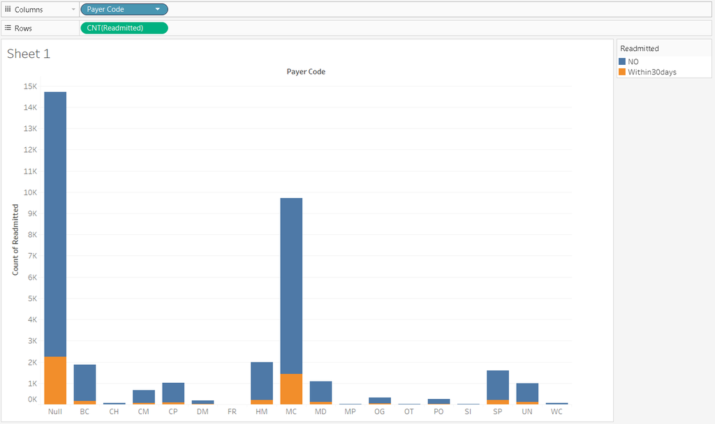

```python
Image(filename='M:/Bckup/aft_cllg/PHD/PHD_Last_act/PLOTS/drugs/Payer_code.PNG')
```

```python
High_risk = ["MC", "UNKNOWN"]
for i,val in enumerate(df['payer_code']):
    if val in High_risk:
        df['payer_code'][i] = 'High_risk'
    else:
        df['payer_code'][i] = 'Low_risk'
```

```python
High_risk = ["MC", "UNKNOWN"]
for i,val in enumerate(testdf['payer_code']):
    if val in High_risk:
        testdf['payer_code'][i] = 'High_risk'
    else:
        testdf['payer_code'][i] = 'Low_risk'
```

##### Replacing gender, change, diabetes med with binary numeric representation.

```python
df['change'] = df['change'].replace('Ch', 1)
df['change'] = df['change'].replace('No', 0)
df['gender'] = df['gender'].replace('Female', 1)
df['gender'] = df['gender'].replace('Male', 0)
df['diabetesMed'] = df['diabetesMed'].replace('Yes', 0)
df['diabetesMed'] = df['diabetesMed'].replace('No', 1)
```

```python
testdf['change'] = testdf['change'].replace('Ch', 1)
testdf['change'] = testdf['change'].replace('No', 0)
testdf['gender'] = testdf['gender'].replace('Female', 1)
testdf['gender'] = testdf['gender'].replace('Male', 0)
testdf['diabetesMed'] = testdf['diabetesMed'].replace('Yes', 0)
testdf['diabetesMed'] = testdf['diabetesMed'].replace('No', 1)
```

##### Missing information in the various drug related columns

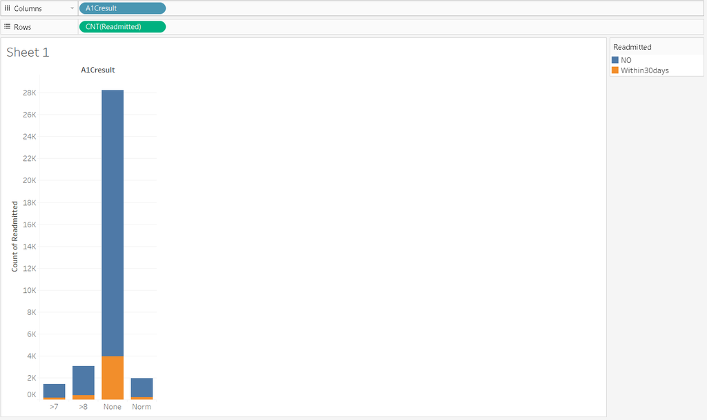

```python
Image(filename='M:/Bckup/aft_cllg/PHD/PHD_Last_act/PLOTS/drugs/A1Cresult.PNG')
```

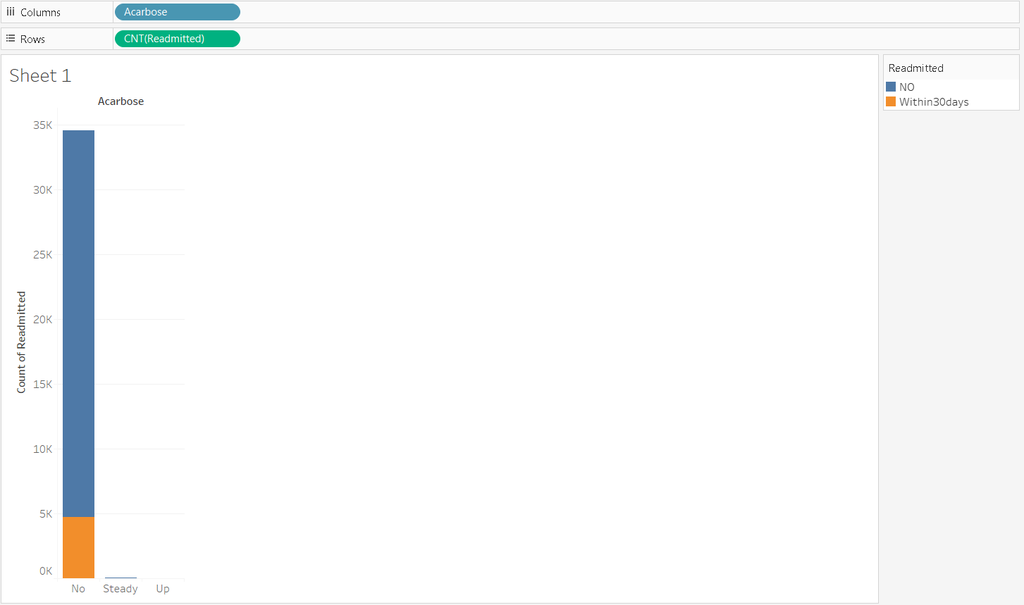

```python
Image(filename='M:/Bckup/aft_cllg/PHD/PHD_Last_act/PLOTS/drugs/Acarbose.PNG')
```

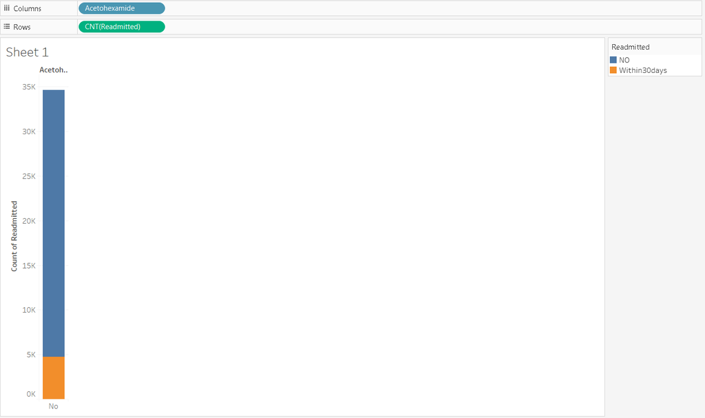

```python
Image(filename='M:/Bckup/aft_cllg/PHD/PHD_Last_act/PLOTS/drugs/Acetohexamide.PNG')
```

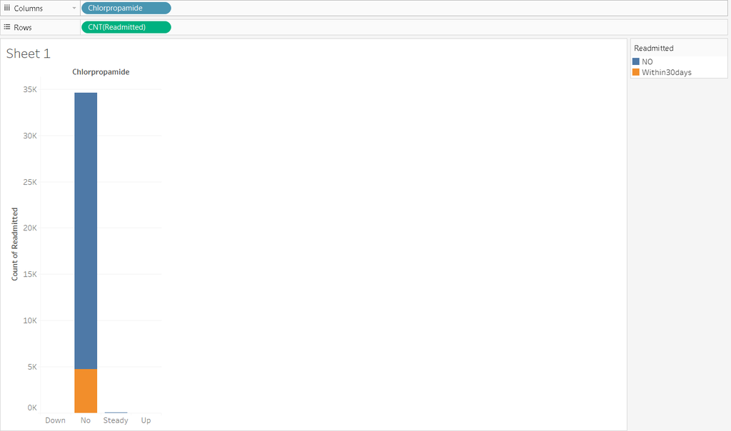

```python
Image(filename='M:/Bckup/aft_cllg/PHD/PHD_Last_act/PLOTS/drugs/Chloropropamide.PNG')
```

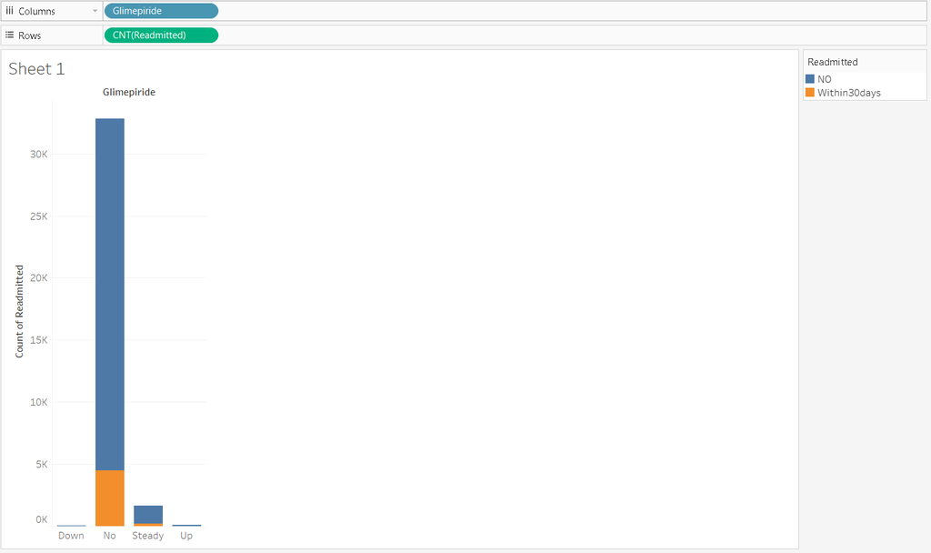

```python
Image(filename='M:/Bckup/aft_cllg/PHD/PHD_Last_act/PLOTS/drugs/Glimepiride.PNG')
```

Simmilarly there are more columns which have a "missing information" problem.

Drugs to drop due to missing information - acarbose, acetohexamide, chloropropamide, glimepiride, glipizide, glipizide.metmorfin, glyburide, glyburide.metmorfin, Max, Glu serum, Metformin.Pioglitazone, Metmorfin.Rosiglitazone, Miglitol, Nateglinide, Pioglitazone, Repaglinide, Roziglitazone, Tolazamide, Tolbutamide, Troglitazone.

```python
df.drop(['acarbose', 'acetohexamide', 'chlorpropamide', 'glimepiride', 'glipizide', 'glipizide.metformin', 'glyburide', 'glyburide.metformin', 'max_glu_serum', 'metformin.pioglitazone', 'metformin.rosiglitazone', 'miglitol', 'nateglinide', 'pioglitazone', 'repaglinide', 'rosiglitazone', 'tolazamide', 'troglitazone'], axis=1,inplace=True)
```

```python
testdf.drop(['acarbose', 'acetohexamide', 'chlorpropamide', 'glimepiride', 'glipizide', 'glipizide.metformin', 'glyburide', 'glyburide.metformin', 'max_glu_serum', 'metformin.pioglitazone', 'metformin.rosiglitazone', 'miglitol', 'nateglinide', 'pioglitazone', 'repaglinide', 'rosiglitazone', 'tolazamide', 'troglitazone'], axis=1,inplace=True)
```

```python
df.drop(['tolbutamide'],axis=1,inplace=True)
```

```python
testdf.drop(['tolbutamide'],axis=1,inplace=True)
```

Based on tableau visualizations -> Bins for Medical_speciality - high risk - cardiology, Emergency Trauma, Family/General Practise, Internal Medicine surgery general, UNKNOWN. Else, low risk.

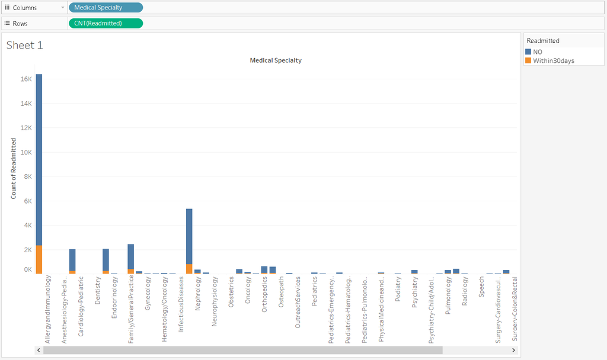

```python
Image(filename='M:/Bckup/aft_cllg/PHD/PHD_Last_act/PLOTS/drugs/medical_speciality.PNG')
```

```python
df.medical_specialty.value_counts().T
```

```
UNKOWN                                  16394
InternalMedicine                         5347
Family/GeneralPractice                   2441
Emergency/Trauma                         2061
Cardiology                               2023
Surgery-General                          1106
Orthopedics                               632
Orthopedics-Reconstructive                565
Radiologist                               413
ObstetricsandGynecology                   365
Nephrology                                331
Psychiatry                                322
Pulmonology                               301
Surgery-Cardiovascular/Thoracic           294
Urology                                   289
Surgery-Neuro                             243
Gastroenterology                          198
Surgery-Vascular                          173
Oncology                                  121
PhysicalMedicineandRehabilitation         106
Neurology                                 105
Pediatrics                                100
Pediatrics-Endocrinology                   92
Hematology/Oncology                        66
Otolaryngology                             58
Endocrinology                              46
Surgery-Thoracic                           45
Pediatrics-CriticalCare                    37
Surgery-Cardiovascular                     37
Gynecology                                 32
                                        ...
Hospitalist                                19
InfectiousDiseases                         17
Osteopath                                  15
SurgicalSpecialty                          11
Obstetrics                                 10
Obsterics&Gynecology-GynecologicOnco        8
Rheumatology                                6
Endocrinology-Metabolism                    5
Surgery-Maxillofacial                       5
Anesthesiology-Pediatric                    5
Psychiatry-Child/Adolescent                 5
Pediatrics-Neurology                        4
Pathology                                   4
PhysicianNotFound                           4
Anesthesiology                              4
Surgery-Pediatric                           4
OutreachServices                            3
DCPTEAM                                     3
Pediatrics-Hematology-Oncology              3
Cardiology-Pediatric                        3
Surgery-Colon&Rectal                        2
Dentistry                                   1
Psychiatry-Addictive                        1
Perinatology                                1
Pediatrics-EmergencyMedicine                1
Proctology                                  1
Pediatrics-Pulmonology                      1
AllergyandImmunology                        1
Speech                                      1
Neurophysiology                             1
Name: medical_specialty, Length: 67, dtype: int64
```

```python
risky_med = ['Cardiology', 'InternalMedicine', 'UNKOWN', 'Emergency/Trauma', 'Family/GeneralPractice', 'Surgery-General']
for i,val in enumerate(df['medical_specialty']):
    if val in risky_med:
        df['medical_specialty'][i] = 'risky_med'
    else:
        df['medical_specialty'][i] = 'low_risk'
```

```python
risky_med = ['Cardiology', 'InternalMedicine', 'UNKOWN', 'Emergency/Trauma', 'Family/GeneralPractice', 'Surgery-General']
for i,val in enumerate(testdf['medical_specialty']):
    if val in risky_med:
        testdf['medical_specialty'][i] = 'risky_med'
    else:
        testdf['medical_specialty'][i] = 'low_risk'
```

```python
less_days = [1, 2, 3]
enough_days = [4, 5, 6, 7, 8, 9, 10, 11, 12, 13, 14, 15]
for i,val in enumerate(df['Date_diff']):
    if val in referral:
        df['Date_diff'][i]='less_days'
    else:
        df['Date_diff'][i]='enough_days'
```

```python
less_days = [1, 2, 3]
enough_days = [4, 5, 6, 7, 8, 9, 10, 11, 12, 13, 14, 15]
for i,val in enumerate(testdf['Date_diff']):
    if val in referral:
        testdf['Date_diff'][i]='less_days'
    else:
        testdf['Date_diff'][i]='enough_days'
```

```python
drugs =["insulin","metformin"]
for col in drugs:
    df[col] = df[col].replace('No', 0)
    df[col] = df[col].replace('Steady', 1)
    df[col] = df[col].replace('Up', 1)
    df[col] = df[col].replace('Down', 1)
```

```python
drugs =["insulin","metformin"]
for col in drugs:
    testdf[col] = testdf[col].replace('No', 0)
    testdf[col] = testdf[col].replace('Steady', 1)
    testdf[col] = testdf[col].replace('Up', 1)
    testdf[col] = testdf[col].replace('Down', 1)
```

```python
df.to_csv("M:/Bckup/aft_cllg/PHD/PHD_Last_act/Final_shit/testcsvs/train_1.csv", index=None)
```

```python
testdf.to_csv("M:/Bckup/aft_cllg/PHD/PHD_Last_act/Final_shit/testcsvs/test_1.csv", index=None)
```

```python
df = pd.read_csv("M:/Bckup/aft_cllg/PHD/PHD_Last_act/Final_shit/testcsvs/train_1.csv", index_col=None)
```

```python
testdf = pd.read_csv("M:/Bckup/aft_cllg/PHD/PHD_Last_act/Final_shit/testcsvs/test_1.csv", index_col=None)
```

```python
df.head(5)
```

|  | race | gender | age | readmitted | num_lab_procedures | num_procedures | num_medications | num_diagnoses | A1Cresult | metformin | ... | diabetesMed | admission_type_id | discharge_disposition_id | admission_source_id | payer_code | medical_specialty | diag_1 | diag_2 | diag_3 | Date_diff |
| --- | --- | --- | --- | --- | --- | --- | --- | --- | --- | --- | --- | --- | --- | --- | --- | --- | --- | --- | --- | --- | --- |
| 0 | Caucasian | 0 | 85 | 0 | 18 | 1 | 7 | 7 | None | 0 | ... | 0 | 1 | Transfer | Emergency | Low_risk | risky_med | 2 | 7 | 3 | enough_days |
| 1 | Caucasian | 0 | 75 | 0 | 40 | 4 | 16 | 9 | None | 0 | ... | 0 | 1 | Transfer | Emergency | Low_risk | risky_med | 2 | 3 | 4 | enough_days |
| 2 | UNKOWN | 1 | 65 | 0 | 39 | 1 | 12 | 5 | None | 0 | ... | 0 | 1 | Transfer | referral | High_risk | risky_med | 8 | 3 | 7 | enough_days |
| 3 | Caucasian | 1 | 75 | 0 | 1 | 0 | 10 | 9 | None | 0 | ... | 0 | 1 | Transfer | Emergency | High_risk | risky_med | 15 | 7 | 15 | enough_days |
| 4 | Caucasian | 1 | 65 | 1 | 44 | 0 | 16 | 9 | None | 0 | ... | 0 | 1 | Transfer | Emergency | Low_risk | risky_med | 3 | 16 | 7 | enough_days |

5 rows × 22 columns

```python
testdf.head(5)
```

|  | race | gender | age | num_lab_procedures | num_procedures | num_medications | num_diagnoses | A1Cresult | metformin | insulin | ... | diabetesMed | admission_type_id | discharge_disposition_id | admission_source_id | payer_code | medical_specialty | diag_1 | diag_2 | diag_3 | Date_diff |
| --- | --- | --- | --- | --- | --- | --- | --- | --- | --- | --- | --- | --- | --- | --- | --- | --- | --- | --- | --- | --- | --- |
| 0 | Caucasian | 1 | 65 | 49 | 0 | 9 | 9 | None | 0 | 0 | ... | 1 | 1 | Transfer | Emergency | Low_risk | risky_med | 1 | 3 | 8 | enough_days |
| 1 | Caucasian | 0 | 55 | 42 | 3 | 28 | 7 | >8 | 1 | 1 | ... | 0 | 3 | Transfer | referral | Low_risk | low_risk | 7 | 16 | 7 | enough_days |
| 2 | Caucasian | 1 | 55 | 61 | 1 | 15 | 6 | >8 | 0 | 1 | ... | 0 | 5 | Transfer | Emergency | Low_risk | risky_med | 2 | 2 | 2 | enough_days |
| 3 | AfricanAmerican | 1 | 45 | 35 | 4 | 29 | 8 | None | 1 | 0 | ... | 0 | 3 | unavail_other | referral | Low_risk | low_risk | 9 | 6 | 9 | enough_days |
| 4 | Caucasian | 1 | 65 | 56 | 1 | 22 | 9 | None | 0 | 0 | ... | 1 | 1 | Transfer | transfer | High_risk | risky_med | 3 | 3 | 15 | enough_days |

5 rows × 21 columns

# T A B L E A U -- V I S U A L I Z A T I O N

### Admission_id Vs Count of readmission

Admission_type_id - description

1. Emergency
2. Urgent
3. Elective
4. Newborn
5. Not Available
6. NULL
7. Trauma Center
8. Not Mapped

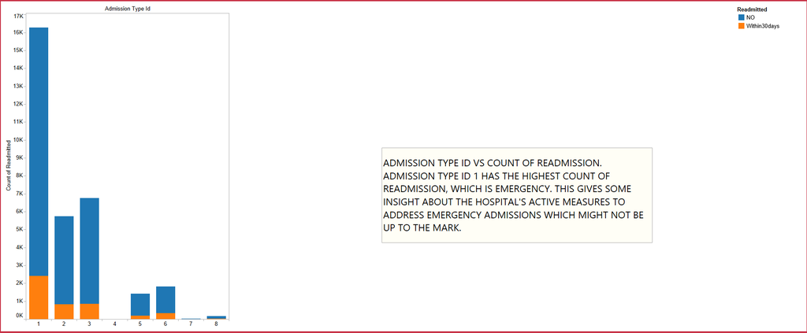

```python
Image(filename='M:/Bckup/aft_cllg/PHD/PHD_Last_act/PLOTS/Tab/Admission_id_vs_Counts.PNG')
```

### Admission_source_id Vs Count of readmission

admission_source_id - description

1. Physician Referral
2. Clinic Referral
3. HMO Referral
4. Transfer from a hospital
5. Transfer from a Skilled Nursing Facility (SNF)
6. Transfer from another health care facility
7. Emergency Room
8. Court/Law Enforcement
9. Not Available
10. Transfer from critial access hospital
11. Normal Delivery
12. Premature Delivery
13. Sick Baby
14. Extramural Birth
15. Not Available
16. NULL
17. Transfer From Another Home Health Agency
18. Readmission to Same Home Health Agency
19. Not Mapped
20. Unknown/Invalid
21. Transfer from hospital inpt/same fac reslt in a sep claim
22. Born inside this hospital
23. Born outside this hospital
24. Transfer from Ambulatory Surgery Center
25. Transfer from Hospice

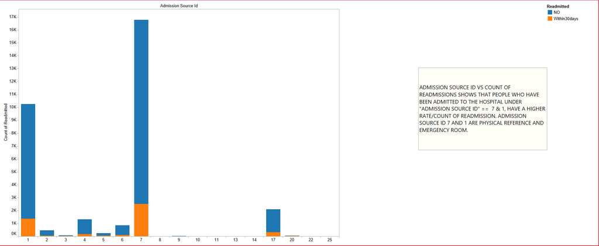

```python
Image(filename='M:/Bckup/aft_cllg/PHD/PHD_Last_act/PLOTS/Tab/Admission_source_id_vs_count.PNG')
```

### Age & Gender Vs Count of readmission

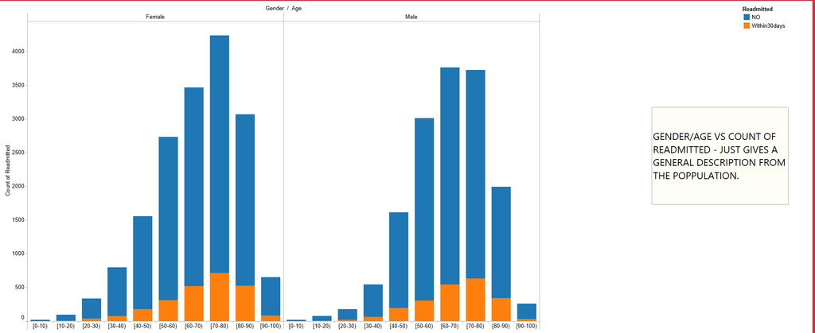

```python
Image(filename='M:/Bckup/aft_cllg/PHD/PHD_Last_act/PLOTS/Tab/Age_&_Gender_vs_Counts.PNG')
```

### Age Vs Count of readmission

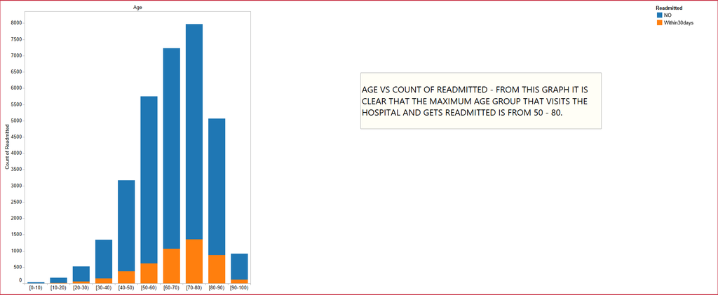

```python
Image(filename='M:/Bckup/aft_cllg/PHD/PHD_Last_act/PLOTS/Tab/Age_vs_count.PNG')
```

### Discharge disposition id & Diabetes Med VS Count of Readmissions

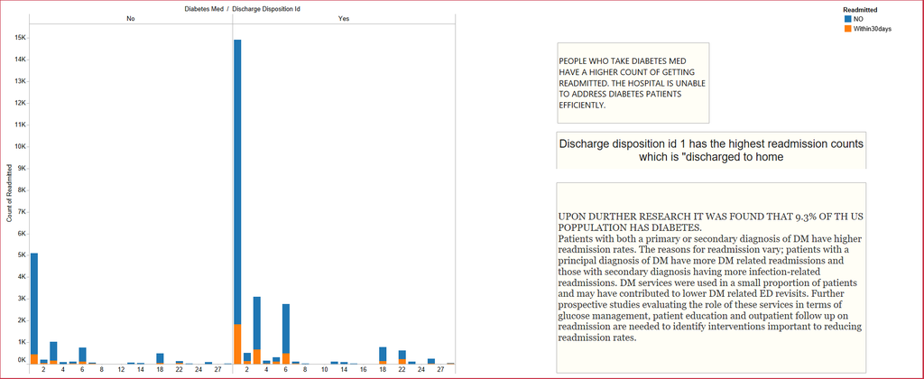

```python
Image(filename='M:/Bckup/aft_cllg/PHD/PHD_Last_act/PLOTS/Tab/Diabetes_med_&_dispositions_id_vs_counts.PNG')
```

### Discharge Disposition ID vs Count of readmissions

discharge_disposition_id - description

1. Discharged to home
2. Discharged/transferred to another short term hospital
3. Discharged/transferred to SNF
4. Discharged/transferred to ICF
5. Discharged/transferred to another type of inpatient care institution
6. Discharged/transferred to home with home health service
7. Left AMA
8. Discharged/transferred to home under care of Home IV provider
9. Admitted as an inpatient to this hospital
10. Neonate discharged to another hospital for neonatal aftercare
11. Expired
12. Still patient or expected to return for outpatient services
13. Hospice / home
14. Hospice / medical facility
15. Discharged/transferred within this institution to Medicare approved swing bed
16. Discharged/transferred/referred another institution for outpatient services
17. Discharged/transferred/referred to this institution for outpatient services
18. NULL
19. "Expired at home. Medicaid only, hospice."
20. "Expired in a medical facility. Medicaid only, hospice."
21. "Expired, place unknown. Medicaid only, hospice."
22. Discharged/transferred to another rehab fac including rehab units of a hospital .
23. Discharged/transferred to a long term care hospital.
24. Discharged/transferred to a nursing facility certified under Medicaid but not certified under Medicare.
25. Not Mapped
26. Unknown/Invalid
27. Discharged/transferred to another Type of Health Care Institution not Defined Elsewhere
28. Discharged/transferred to a federal health care facility.
29. Discharged/transferred/referred to a psychiatric hospital of psychiatric distinct part unit of a hospital
30. Discharged/transferred to a Critical Access Hospital (CAH).

[figure not shown]

```python
Image(filename='M:/Bckup/aft_cllg/PHD/PHD_Last_act/PLOTS/Tab/Discharge_disposition_id_vs_counts.PNG')
```

### Number of Diagnosis Vs Count of Readmissions

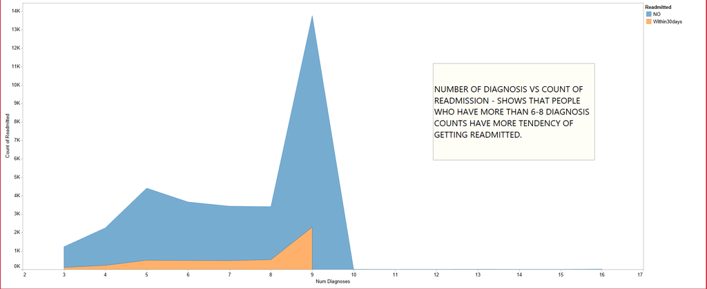

```python
Image(filename='M:/Bckup/aft_cllg/PHD/PHD_Last_act/PLOTS/Tab/Num_diagnosis_vs_counts.PNG')
```

### Number of medications & number of procedures & Number of lab procedures VS Count of Readmissions

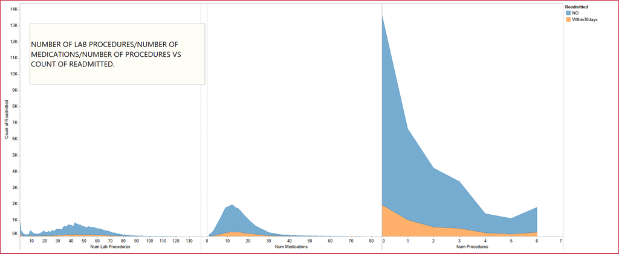

```python
Image(filename='M:/Bckup/aft_cllg/PHD/PHD_Last_act/PLOTS/Tab/Num_lab_procedures_&_numMedications_num_procedures_vs_counts.PNG')
```

### Number of Days Spent in hospital Vs Count of Readmission

A date difference column was created by subtracting admission date and discharge date.

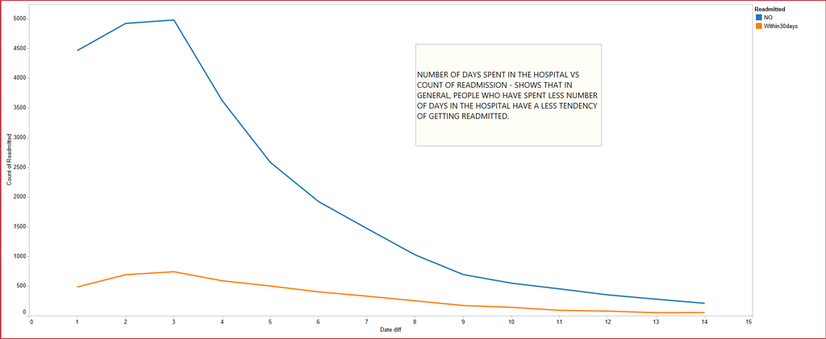

```python
Image(filename='M:/Bckup/aft_cllg/PHD/PHD_Last_act/PLOTS/Tab/Number_of_days_spent_vs_counts.PNG')
```

This gives us a hint that people who have longer stays in the hospital either have ritical medical issues and henceare getting readmitted within 30 days or the quality of care provided by the hospital for these people is not up to the mark.

### Race & Age VS Count Of Readmissions

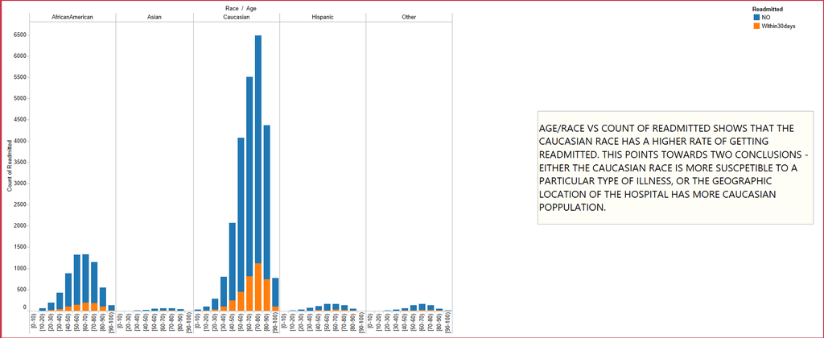

```python
Image(filename='M:/Bckup/aft_cllg/PHD/PHD_Last_act/PLOTS/Tab/Race_&_age_vs_counts.PNG')
```

### Diagnosis Classes Vs Count of readmissions

### The following is a list of codes for International Statistical Classification of Diseases and Related Health Problems - for reference in the figure.

# -List of ICD-9 codes 001–139: infectious and parasitic diseases

# -List of ICD-9 codes 140–239: neoplasms

# -List of ICD-9 codes 240–279: endocrine, nutritional and metabolic diseases, and immunity disorders

# -List of ICD-9 codes 280–289: diseases of the blood and blood-forming organs

# -List of ICD-9 codes 290–319: mental disorders

# -List of ICD-9 codes 320–389: diseases of the nervous system and sense organs

# -List of ICD-9 codes 390–459: diseases of the circulatory system

# -List of ICD-9 codes 460–519: diseases of the respiratory system

# -List of ICD-9 codes 520–579: diseases of the digestive system

# -List of ICD-9 codes 580–629: diseases of the genitourinary system

# -List of ICD-9 codes 630–679: complications of pregnancy, childbirth, and the puerperium

# -List of ICD-9 codes 680–709: diseases of the skin and subcutaneous tissue

# -List of ICD-9 codes 710–739: diseases of the musculoskeletal system and connective tissue

# -List of ICD-9 codes 740–759: congenital anomalies

# -List of ICD-9 codes 760–779: certain conditions originating in the perinatal period

# -List of ICD-9 codes 780–799: symptoms, signs, and ill-defined conditions

# -List of ICD-9 codes 800–999: injury and poisoning

# -List of ICD-9 codes E and V codes: external causes of injury and supplemental classification

###### Source - wikipedia

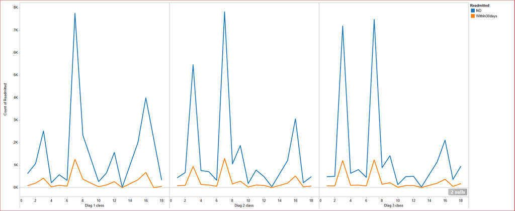

```python
Image(filename='M:/Bckup/aft_cllg/PHD/PHD_Last_act/PLOTS/Tab/Diagnosis_classes_vs_count.PNG')
```

### Diagnosis classes & Race & Gender VS Count of Readmissions

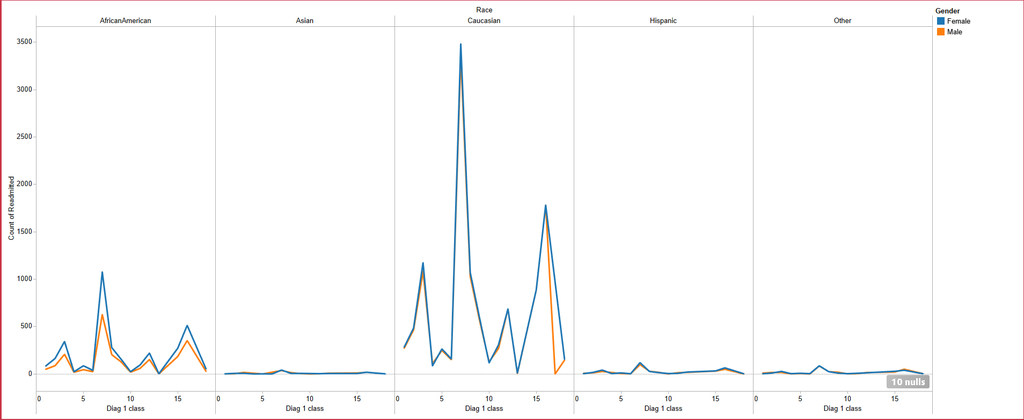

```python
Image(filename='M:/Bckup/aft_cllg/PHD/PHD_Last_act/PLOTS/Tab/Diagnosis classes_race_gender Vs Count.PNG')
```

This tells us that caucasian and African/American people (both male and female, but relatively more female) have higher tendency of getting diagnosed with diagnosis class 7 which is diseases related to the circulatory system.

### CLASS IMBALANCE -

[figure not shown]

```python
Image(filename='M:/Bckup/aft_cllg/PHD/PHD_Last_act/PLOTS/Tab/class_imbalance.PNG')
```

### Dummification for Model building

```python
df.dtypes
testdf.dtypes
```

```
race                        object
gender                       int64
age                          int64
num_lab_procedures           int64
num_procedures               int64
num_medications              int64
num_diagnoses                int64
A1Cresult                   object
metformin                    int64
insulin                      int64
change                       int64
diabetesMed                  int64
admission_type_id            int64
discharge_disposition_id    object
admission_source_id         object
payer_code                  object
medical_specialty           object
diag_1                      object
diag_2                      object
diag_3                      object
Date_diff                   object
dtype: object
```

### This is a function to extract categorical and numerical features from the dataframe.

```python
def seperate_cat_num(data):
    cat_Var_Names = []
    num_Var_Names = []
    for i in data.columns:
        if(data[i].dtypes=="object"):
            cat_Var_Names.append(i)
        else:
                num_Var_Names.append(i)
    return cat_Var_Names,num_Var_Names
```

```python
cat_Var_Names,num_Var_Names = seperate_cat_num(df)
```

```python
cat_Var_Names_test,num_Var_Names_test = seperate_cat_num(testdf)
```

```python
move = ('gender','change','diabetesMed','admission_type_id')
```

```python
num_Var_Names_test.append('age')
```

```python
cat_Var_Names_test.remove('age')
```

```python
for i in move:
    cat_Var_Names_test.append(i)
    num_Var_Names_test.remove(i)
```

```python
for i in move:
    cat_Var_Names.append(i)
    num_Var_Names.remove(i)
```

```python
cat_Var_Names
```

```
['race',
 'A1Cresult',
 'discharge_disposition_id',
 'admission_source_id',
 'payer_code',
 'medical_specialty',
 'Date_diff',
 'gender',
 'change',
 'diabetesMed',
 'admission_type_id',
 'metformin',
 'insulin',
 'diag_1',
 'diag_2',
 'diag_3']
```

```python
num_Var_Names_test
```

```
['age',
 'num_lab_procedures',
 'num_procedures',
 'num_medications',
 'num_diagnoses',
 'metformin',
 'insulin',
 'diag_1',
 'diag_2',
 'diag_3',
 'age']
```

```python
for i in num_Var_Names_test[4:]:
    cat_Var_Names_test.append(i)
    num_Var_Names_test.remove(i)
```

```python
cat_Var_Names_test.remove('num_diagnoses')
num_Var_Names_test.append('num_diagnoses')
```

```python
num_Var_Names_test
```

```
['num_lab_procedures', 'num_procedures', 'num_medications', 'age']
```

```python
for i in num_Var_Names[5:]:
    cat_Var_Names.append(i)
    num_Var_Names.remove(i)
```

```python
num_Var_Names.remove('readmitted')
cat_Var_Names.remove('readmitted')
```

[output not shown]

```python
for i in df[cat_Var_Names]:
    df[i]=df[i].astype("category")
```

```python
for i in testdf[cat_Var_Names_test]:
    testdf[i]=testdf[i].astype("category")
```

```python
df.apply(pd.Series.nunique)
```

```
race                          6
gender                        2
age                          10
readmitted                    2
num_lab_procedures          112
num_procedures                7
num_medications              74
num_diagnoses                16
A1Cresult                     4
metformin                     2
insulin                       2
change                        2
diabetesMed                   2
admission_type_id             4
discharge_disposition_id      4
admission_source_id           5
payer_code                    2
medical_specialty             2
diag_1                       16
diag_2                       16
diag_3                       16
Date_diff                     1
dtype: int64
```

```python
testdf.apply(pd.Series.nunique)
```

```
race                          6
gender                        2
age                          10
num_lab_procedures          108
num_procedures                7
num_medications              69
num_diagnoses                16
A1Cresult                     4
metformin                     2
insulin                       2
change                        2
diabetesMed                   2
admission_type_id             4
discharge_disposition_id      4
admission_source_id           5
payer_code                    2
medical_specialty             2
diag_1                       16
diag_2                       16
diag_3                       16
Date_diff                     1
dtype: int64
```

```python
dummy_train = pd.get_dummies(df, columns=cat_Var_Names)
```

```python
dummy_test = pd.get_dummies(testdf, columns=cat_Var_Names_test)
```

```python
dummy_train.shape
```

```
(34650, 92)
```

```python
dummy_test.shape
```

```
(14630, 91)
```

##### For prediction on actual test, saving the dummified columns in a different df.

```python
y_final=dummy_train["readmitted"]
X_final=dummy_train.drop("readmitted", axis=1)
```

### UPSAMPLING OF full Train data for best prediction on actual test data

```python
from sklearn.utils import resample


# concatenate our training data back together
X = pd.concat([X_final, y_final], axis=1)

# separate minority and majority classes
not_re_admitted = X[X.readmitted==0]
readmitted = X[X.readmitted==1]

# upsample minority
readmission_upsampled = resample(readmitted,
                          replace=True, # sample with replacement
                          n_samples=len(not_re_admitted), # match number in majority class
                          random_state=1) # reproducible results

# combine majority and upsampled minority
final_df = pd.concat([not_re_admitted, readmission_upsampled])

# check new class counts
final_df.readmitted.value_counts()
```

```
1    29891
0    29891
Name: readmitted, dtype: int64
```

```python
final_df.shape
```

```
(59782, 92)
```

### THE -- M E T R I C -- THING:

The given metric for the problem statement is 'recall', which makes sense as one would like to rather focus on increasing the count of predictions for the class of people getting readmitted. However, as one tends to increase the recall for one class, accuracy tends to go down, logically. The most optimised model here would be the one which can increase the recall for our desired calss while maintaining accuracy at a decent level. Now, it is also important that we predict the desired class as precisely as possible. To ensure this we shall look at precision scores for all models as well.

#### CONFUSION MATRIX

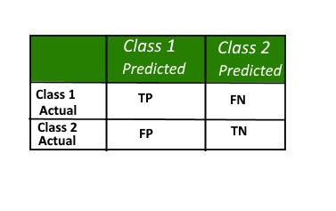

```python
Image(filename='M:/Bckup/aft_cllg/PHD/PHD_Last_act/PLOTS/conf_mat.png')
```

#### • Positive (P) : Observation is positive (for example: is an apple).

#### • Negative (N) : Observation is not positive (for example: is not an apple).

#### • True Positive (TP) : Observation is positive, and is predicted to be positive.

#### • False Negative (FN) : Observation is positive, but is predicted negative.

#### • True Negative (TN) : Observation is negative, and is predicted to be negative.

#### • False Positive (FP) : Observation is negative, but is predicted positive.

##### Accuracy = (TP + TN) / (TP + TN + FP +FN)

##### Recall = TP / (TP + FN)

##### Precision = TP / (TP + FP) - high recall, low precision problem and vice-versa.

##### The given data set also has a huge class imbalance issue. Upsampling will be used to train the model to deal with this issue. A function to check prevalance will also be employed in order to validate the training. One can't expect a model which has been trained on 14% of a particular to class to be good at classification.

```python
def calc_prevalence(y_actual):
    return (sum(y_actual)/len(y_actual))
```

###### All the functions have been joined under one function - print_report.

```python
from sklearn.metrics import roc_auc_score, accuracy_score, precision_score, recall_score
def calc_specificity(y_actual, y_pred, thresh):
    # calculates specificity
    return sum((y_pred < thresh) & (y_actual == 0)) /sum(y_actual ==0)

def print_report(y_actual, y_pred, thresh):

    auc = roc_auc_score(y_actual, y_pred)
    accuracy = accuracy_score(y_actual, (y_pred > thresh))
    recall = recall_score(y_actual, (y_pred > thresh))
    precision = precision_score(y_actual, (y_pred > thresh))
    specificity = calc_specificity(y_actual, y_pred, thresh)
    print('AUC:%.3f'%auc)
    print('accuracy:%.3f'%accuracy)
    print('recall:%.3f'%recall)
    print('precision:%.3f'%precision)
    print('specificity:%.3f'%specificity)
    print('prevalence:%.3f'%calc_prevalence(y_actual))
    print(' ')
    return auc, accuracy, recall, precision, specificity
```

```python
thresh = 0.5
```

```python
dummy_train.shape
```

```
(34650, 92)
```

```python
dummy_test.shape
```

```
(14630, 91)
```

Defining a function to plot learning curve from the scikit-learn site link - https://scikit-learn.org/stable/auto_examples/model_selection/plot_learning_curve.html. Changing the plot from accuracy to AUC.

```python
import numpy as np
from sklearn.model_selection import learning_curve
from sklearn.model_selection import ShuffleSplit

def plot_learning_curve(estimator, title, X, y, ylim=None, cv=None,
                        n_jobs=1, train_sizes=np.linspace(.1, 1.0, 5)):
    """
    Generate a simple plot of the test and training learning curve.

    Parameters
    ----------
    estimator : object type that implements the "fit" and "predict" methods
        An object of that type which is cloned for each validation.

    title : string
        Title for the chart.

    X : array-like, shape (n_samples, n_features)
        Training vector, where n_samples is the number of samples and
        n_features is the number of features.

    y : array-like, shape (n_samples) or (n_samples, n_features), optional
        Target relative to X for classification or regression;
        None for unsupervised learning.

    ylim : tuple, shape (ymin, ymax), optional
        Defines minimum and maximum yvalues plotted.

    cv : int, cross-validation generator or an iterable, optional
        Determines the cross-validation splitting strategy.
        Possible inputs for cv are:
          - None, to use the default 3-fold cross-validation,
          - integer, to specify the number of folds.
          - An object to be used as a cross-validation generator.
          - An iterable yielding train/test splits.

        For integer/None inputs, if ``y`` is binary or multiclass,
        :class:`StratifiedKFold` used. If the estimator is not a classifier
        or if ``y`` is neither binary nor multiclass, :class:`KFold` is used.

        Refer :ref:`User Guide <cross_validation>` for the various
        cross-validators that can be used here.

    n_jobs : integer, optional
        Number of jobs to run in parallel (default 1).
    """
    plt.figure()
    plt.title(title)
    if ylim is not None:
        plt.ylim(*ylim)
    plt.xlabel("Training examples")
    plt.ylabel("AUC")
    train_sizes, train_scores, test_scores = learning_curve(
        estimator, X, y, cv=cv, n_jobs=n_jobs, train_sizes=train_sizes, scoring = 'roc_auc')
    train_scores_mean = np.mean(train_scores, axis=1)
    train_scores_std = np.std(train_scores, axis=1)
    test_scores_mean = np.mean(test_scores, axis=1)
    test_scores_std = np.std(test_scores, axis=1)
    plt.grid()

    plt.fill_between(train_sizes, train_scores_mean - train_scores_std,
                     train_scores_mean + train_scores_std, alpha=0.1,
                     color="r")
    plt.fill_between(train_sizes, test_scores_mean - test_scores_std,
                     test_scores_mean + test_scores_std, alpha=0.1, color="b")
    plt.plot(train_sizes, train_scores_mean, 'o-', color="r",
             label="Training score")
    plt.plot(train_sizes, test_scores_mean, 'o-', color="b",
             label="Cross-validation score")

    plt.legend(loc="best")
    return plt
```

# M O D E L S ->

```python
from sklearn.model_selection import train_test_split
```

```python
y=dummy_train["readmitted"]
X=dummy_train.drop("readmitted", axis=1)
X_train, X_test, y_train, y_test = train_test_split(X,y,test_size=0.20,random_state=1)
```

```python
print(X_train.shape)
print(X_test.shape)
print(y_train.shape)
print(y_test.shape)
```

```
(27720, 91)
(6930, 91)
(27720,)
(6930,)
```

### U P S A M P L I N G

```python
from sklearn.utils import resample


# concatenate our training data back together
X = pd.concat([X_train, y_train], axis=1)

# separate minority and majority classes
not_re_admitted = X[X.readmitted==0]
readmitted = X[X.readmitted==1]

# upsample minority
readmission_upsampled = resample(readmitted,
                          replace=True, # sample with replacement
                          n_samples=len(not_re_admitted), # match number in majority class
                          random_state=1) # reproducible results

# combine majority and upsampled minority
upsampled = pd.concat([not_re_admitted, readmission_upsampled])

# check new class counts
upsampled.readmitted.value_counts()
```

```
1    23930
0    23930
Name: readmitted, dtype: int64
```

```python
from sklearn.metrics import classification_report
```

### L O G I S T I C -- R E G R E S S I O N

```python
y_train = upsampled.readmitted
X_train = upsampled.drop('readmitted', axis=1)

upsampled_lr = LogisticRegression(solver='liblinear').fit(X_train, y_train)

upsampled_pred = upsampled_lr.predict(X_test)

# Checking accuracy
accuracy_score(y_test, upsampled_pred)

# f1 score
# f1_score(y_test, upsampled_pred)
# scores = ['precision', 'recall']
# recall_score(y_test, upsampled_pred, pos_label=[,'Within30days'])
print(confusion_matrix(y_test, upsampled_pred))
```

[output not shown]

```python
recall_score(y_test, upsampled_pred, pos_label=1)
```

```
0.608875128998968
```

```python
print('Logistic Regression')
print('Validation:')
LogisticRegression_valid_auc, LogisticRegression_valid_accuracy, LogisticRegression_valid_recall, LogisticRegression_valid_precision, LogisticRegression_valid_specificity = print_report(y_test, upsampled_pred, thresh)
```

```
Logistic Regression
Validation:
AUC:0.574
accuracy:0.549
recall:0.609
precision:0.177
specificity:0.539
prevalence:0.140
```

```python
feature_importances = pd.DataFrame(upsampled.coef_[0],index = dummy_test.columns,columns=['importance']).sort_values('importance',ascending=False)
```

```python
feature_importances.head()
```

|  | importance |
| --- | --- |
| discharge_disposition_id_critical | 1.221823 |
| discharge_disposition_id_Transfer | 0.942435 |
| discharge_disposition_id_unavail_other | 0.933139 |
| diag_1_17 | 0.757681 |
| diag_2_2 | 0.378227 |

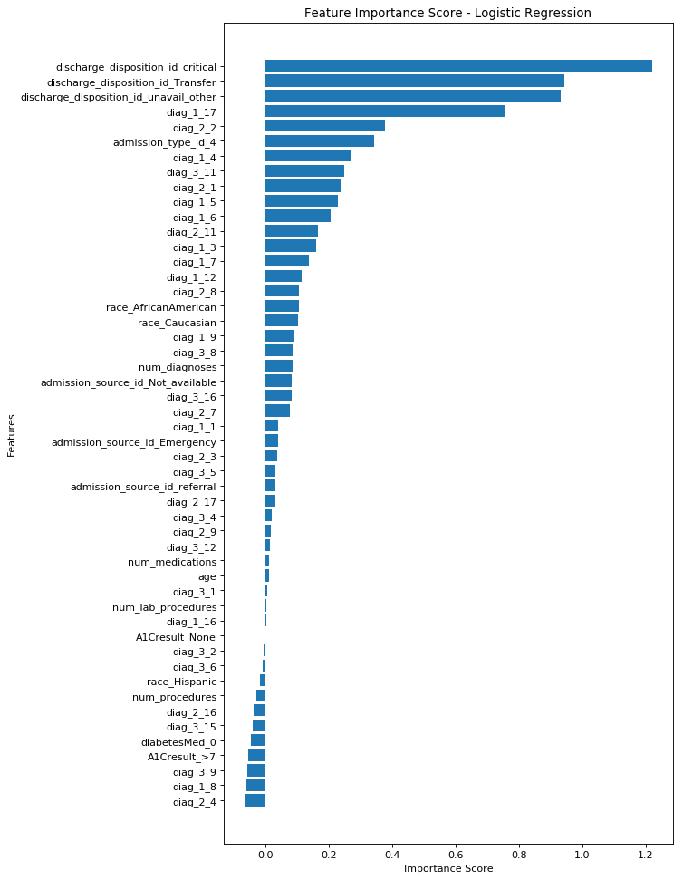

```python
num = 50
ylocs = np.arange(num)
values_to_plot = feature_importances.iloc[:num].values.ravel()[::-1]
feature_labels = list(feature_importances.iloc[:num].index)[::-1]

plt.figure(num=None, figsize=(8, 15), dpi=80, facecolor='w', edgecolor='k');
plt.barh(ylocs, values_to_plot, align = 'center')
plt.ylabel('Features')
plt.xlabel('Importance Score')
plt.title('Feature Importance Score - Logistic Regression')
plt.yticks(ylocs, feature_labels)
plt.show()
```

```python
lrweights = [0.8,0.2]
```

```python
lr = LogisticRegression(penalty = 'l2', random_state = 1)
lr.fit(X_train,y_train)
```

```
LogisticRegression(C=1.0, class_weight=None, dual=False, fit_intercept=True,
          intercept_scaling=1, max_iter=100, multi_class='ovr', n_jobs=1,
          penalty='l2', random_state=1, solver='liblinear', tol=0.0001,
          verbose=0, warm_start=False)
```

```python
lr_pred = lr.predict(X_test)
```

```python
recall_score(y_test, lr_pred, pos_label=1)
```

```
0.608875128998968
```

# S T O C H A S T I C -- G R A D I E N T -- D E S C E N T

```python
from sklearn.linear_model import SGDClassifier
sgdc=SGDClassifier(alpha = 0.1,random_state = 1)
%time sgdc.fit(X_train, y_train)
```

```
Wall time: 205 ms
```

```
SGDClassifier(alpha=0.1, average=False, class_weight=None, epsilon=0.1,
       eta0=0.0, fit_intercept=True, l1_ratio=0.15,
       learning_rate='optimal', loss='hinge', max_iter=None, n_iter=None,
       n_jobs=1, penalty='l2', power_t=0.5, random_state=1, shuffle=True,
       tol=None, verbose=0, warm_start=False)
```

```python
y_test_preds = sgdc.predict(X_test)

print('Stochastic Gradient Descend')
print('Validation:')
sgdc_valid_auc, sgdc_valid_accuracy, sgdc_valid_recall, sgdc_valid_precision, sgdc_valid_specificity = print_report(y_test,y_test_preds, thresh)
```

```
Stochastic Gradient Descend
Validation:
AUC:0.528
accuracy:0.233
recall:0.936
precision:0.147
specificity:0.119
prevalence:0.140
```

```python
feature_importances_sgd = pd.DataFrame(sgdc.coef_[0],index = dummy_test.columns,columns=['importance']).sort_values('importance',ascending=False)
```

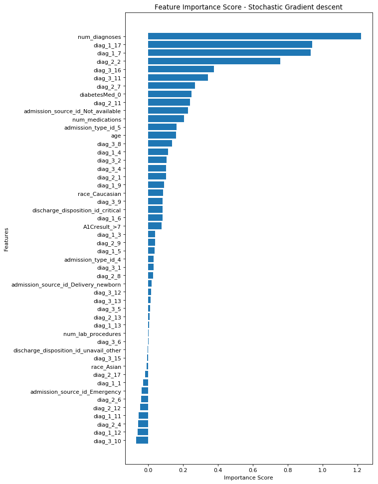

```python
num = 50
ylocs = np.arange(num)
values_to_plot = feature_importances.iloc[:num].values.ravel()[::-1]
feature_labels = list(feature_importances_sgd.iloc[:num].index)[::-1]

plt.figure(num=None, figsize=(8, 15), dpi=80, facecolor='w', edgecolor='k');
plt.barh(ylocs, values_to_plot, align = 'center')
plt.ylabel('Features')
plt.xlabel('Importance Score')
plt.title('Feature Importance Score - Stochastic Gradient descent')
plt.yticks(ylocs, feature_labels)
plt.show()
```

### N A I VE -- B A Y E S

```python
from sklearn.naive_bayes import GaussianNB

nb = GaussianNB(priors = [0.99,0.01])
%time nb.fit(X_train, y_train)
```

```
Wall time: 230 ms
```

```
GaussianNB(priors=[0.99, 0.01])
```

```python
nb.class_prior_
```

[output not shown]

```python
y_test_preds = nb.predict(X_test)

print('Naive Bayes')
print('Validation:')
nb_valid_auc, nb_valid_accuracy, nb_valid_recall, nb_valid_precision, nb_valid_specificity = print_report(y_test,y_test_preds, thresh)
```

```
Naive Bayes
Validation:
AUC:0.531
accuracy:0.246
recall:0.927
precision:0.148
specificity:0.135
prevalence:0.140
```

### D E C I S I O N -- T R E E -- M O D E L

```python
# UPSAMPLED DECISION TREE
estimator = DecisionTreeClassifier(max_depth=4,random_state=1)
estimator.fit(X_train, y_train)

y1_pred_ = estimator.predict(X_train)
y_pred_ = estimator.predict(X_test)

print(accuracy_score(y_train,y1_pred_))
print(classification_report(y_train,y1_pred_,digits=4))
print("\n")

print(accuracy_score(y_test,y_pred_))
print(classification_report(y_test,y_pred_,digits=4))
print(recall_score(y_test, y_pred_, pos_label=1))
```

```
0.5775595486836607
             precision    recall  f1-score   support

          0     0.6461    0.3429    0.4480     23930
          1     0.5528    0.8122    0.6578     23930

avg / total     0.5995    0.5776    0.5529     47860



0.3956709956709957
             precision    recall  f1-score   support

          0     0.9061    0.3318    0.4858      5961
          1     0.1609    0.7884    0.2673       969

avg / total     0.8019    0.3957    0.4552      6930

0.7884416924664602
```

```python
print('Decision Tree')
print('Training:')
estimator_train_auc, estimator_train_accuracy, estimator_train_recall, estimator_train_precision, estimator_train_specificity =print_report(y_train,y1_pred_, thresh)
print('Validation:')
estimator_valid_auc, estimator_valid_accuracy, estimator_valid_recall, estimator_valid_precision, estimator_valid_specificity = print_report(y_test,y_pred_, thresh)
```

```
Decision Tree
Training:
AUC:0.578
accuracy:0.578
recall:0.812
precision:0.553
specificity:0.343
prevalence:0.500

Validation:
AUC:0.560
accuracy:0.396
recall:0.788
precision:0.161
specificity:0.332
prevalence:0.140
```

```python
import graphviz
```

```python
graph_data=export_graphviz(estimator, out_file="M:/Bckup/aft_cllg/PHD/PHD_Last_act/PLOTS/tree_dt.dot", max_depth=None, feature_names=dummy_train.drop(['readmitted'],axis=1).columns, class_names=True, label='all', filled=False, leaves_parallel=False, impurity=True, node_ids=False, proportion=True, rotate=False, rounded=False, special_characters=False, precision=3 )
```

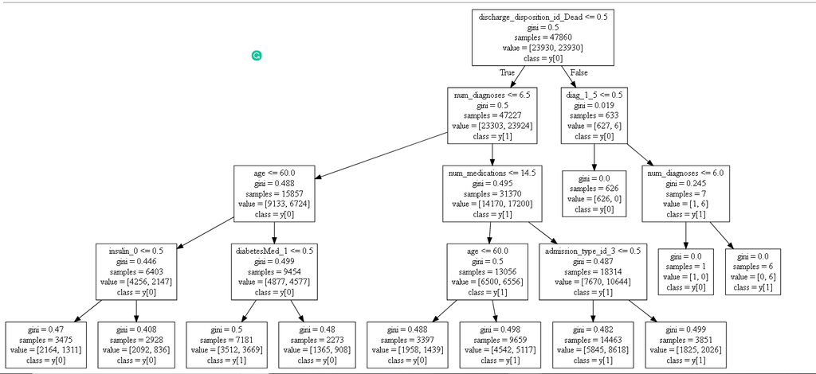

```python
Image(filename='M:/Bckup/aft_cllg/PHD/PHD_Last_act/PLOTS/DT2_tree.PNG')
```

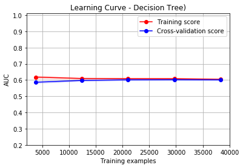

```python
title = "Learning Curve - Decision Tree)"
# Cross validation with 5 iterations to get smoother mean test and train
# score curves, each time with 20% data randomly selected as a validation set.
cv = ShuffleSplit(n_splits=5, test_size=0.2, random_state=1)
plot_learning_curve(estimator, title, X_train, y_train, ylim=(0.2, 1.01), cv=cv, n_jobs=-1)

plt.show()
```

# R A N D O M -- F O R E S T -- C L A S S I F I E R

```python
# from sklearn.ensemble import RandomForestClassifier
from sklearn.ensemble import RandomForestClassifier
```

```python
rf=RandomForestClassifier(max_depth = 6, random_state = 1)
rf.fit(X_train, y_train)
```

```
RandomForestClassifier(bootstrap=True, class_weight=None, criterion='gini',
            max_depth=6, max_features='auto', max_leaf_nodes=None,
            min_impurity_decrease=0.0, min_impurity_split=None,
            min_samples_leaf=1, min_samples_split=2,
            min_weight_fraction_leaf=0.0, n_estimators=10, n_jobs=1,
            oob_score=False, random_state=1, verbose=0, warm_start=False)
```

[output not shown]

```python
y_train_preds = rf.predict(X_train)
y_test_preds = rf.predict(X_test)

print('Random Forest')
print('Training:')
rf_train_auc, rf_train_accuracy, rf_train_recall, rf_train_precision, rf_train_specificity =print_report(y_train,y_train_preds, thresh)
print('Validation:')
rf_valid_auc, rf_valid_accuracy, rf_valid_recall, rf_valid_precision, rf_valid_specificity = print_report(y_test,y_test_preds, thresh)
```

```
Random Forest
Training:
AUC:0.616
accuracy:0.616
recall:0.711
precision:0.598
specificity:0.522
prevalence:0.500

Validation:
AUC:0.562
accuracy:0.523
recall:0.617
precision:0.169
specificity:0.507
prevalence:0.140
```

```python
sample_leaf_options = [1,5,10,50,100,200,500]
```

```python
for leaf_size in sample_leaf_options :
    model = RandomForestClassifier(n_estimators = 200, n_jobs = -1,random_state =50, max_features = "auto", min_samples_leaf = leaf_size)
    model.fit(X_train, y_train)
```

```python
y_train_model = model.predict(X_train)
y_test_model = model.predict(X_test)
```

```python
print('Random Forest _model')
print('Training:')
rf_model_train_auc, rf_model_train_accuracy, rf_model_train_recall, rf_model_train_precision, rf_model_train_specificity =print_report(y_train,y_train_model, thresh)
print('Validation:')
rf_model_valid_auc, rf_model_valid_accuracy, rf_model_valid_recall, rf_model_valid_precision, rf_model_valid_specificity = print_report(y_test,y_test_model, thresh)
```

```
Random Forest _model
Training:
AUC:0.591
accuracy:0.591
recall:0.611
precision:0.588
specificity:0.572
prevalence:0.500

Validation:
AUC:0.576
accuracy:0.571
recall:0.584
precision:0.180
specificity:0.569
prevalence:0.140
```

```python
clf = RandomForestClassifier(n_estimators=500, max_depth=5, criterion="entropy", bootstrap=True,random_state=1)
%time clf.fit(X=X_train, y=y_train)
```

```
Wall time: 10.9 s
```

```
RandomForestClassifier(bootstrap=True, class_weight=None, criterion='entropy',
            max_depth=5, max_features='auto', max_leaf_nodes=None,
            min_impurity_decrease=0.0, min_impurity_split=None,
            min_samples_leaf=1, min_samples_split=2,
            min_weight_fraction_leaf=0.0, n_estimators=500, n_jobs=1,
            oob_score=False, random_state=1, verbose=0, warm_start=False)
```

```python
from sklearn.metrics import accuracy_score
from sklearn.metrics import recall_score

y_pred_test = clf.predict(X_test)
print(accuracy_score(y_test,y_pred_test))
```

```
0.5506493506493506
```

```python
y_pred_train = clf.predict(X_train)
print(accuracy_score(y_train,y_pred_train))
```

```
0.6071249477643126
```

```python
print(recall_score(y_test,y_pred_test,pos_label=1))
```

```
0.6140350877192983
```

```python
print('clf')
print('Training:')
clf_train_auc, clf_train_accuracy, clf_train_recall, clf_train_precision, clf_train_specificity =print_report(y_train,y_pred_train, thresh)
print('Validation:')
clf_valid_auc, clf_valid_accuracy, clf_valid_recall, clf_valid_precision, clf_valid_specificity = print_report(y_test,y_pred_test, thresh)
```

```
clf
Training:
AUC:0.607
accuracy:0.607
recall:0.664
precision:0.596
specificity:0.550
prevalence:0.500

Validation:
AUC:0.577
accuracy:0.551
recall:0.614
precision:0.178
specificity:0.540
prevalence:0.140
```

```python
clf.feature_importances_
```

```
array([1.27732452e-01, 5.30285901e-02, 1.38779949e-02, 8.59588136e-02,
       1.30815331e-01, 2.83642339e-03, 8.30448379e-04, 9.13294285e-03,
       2.35427936e-03, 1.50717054e-03, 6.01993831e-03, 1.25469902e-03,
       3.57626667e-03, 3.69676803e-03, 2.40816074e-03, 1.78196762e-01,
       2.59534727e-02, 3.40303257e-03, 8.63469317e-03, 0.00000000e+00,
       5.75912329e-03, 2.51240947e-03, 4.71896686e-03, 8.31224024e-03,
       4.23170424e-03, 5.14553230e-03, 5.09172099e-03, 4.18671779e-03,
       0.00000000e+00, 1.91823495e-03, 1.65263912e-03, 6.14736191e-03,
       5.54546669e-03, 3.99303219e-02, 4.25804973e-02, 3.50390582e-03,
       9.70334518e-03, 3.59069150e-05, 2.94629439e-03, 3.38721206e-03,
       3.30831804e-03, 1.23945574e-02, 1.23636023e-02, 9.61178073e-04,
       2.73002462e-03, 3.43862900e-03, 1.02302016e-03, 2.91288387e-03,
       1.45454539e-03, 5.10640758e-03, 1.12379591e-03, 2.23200968e-03,
       1.66099265e-02, 5.69266681e-04, 1.09321243e-03, 1.50720196e-04,
       1.54605738e-02, 1.71243474e-03, 1.03186855e-02, 1.22456550e-03,
       8.14918040e-03, 4.68560873e-03, 1.78972428e-03, 1.91826162e-03,
       1.10239838e-03, 3.24532563e-03, 1.78142008e-03, 1.47897625e-03,
       9.14469231e-03, 1.77808338e-03, 1.24822787e-03, 2.62107556e-04,
       1.29610651e-03, 1.70759155e-03, 8.75861198e-04, 9.47809567e-04,
       2.15245292e-03, 1.24581176e-02, 1.24263260e-03, 1.27163086e-03,
       1.13016507e-03, 2.23597172e-03, 1.46852549e-03, 1.27329545e-03,
       5.11307593e-03, 4.41342726e-03, 1.39147643e-03, 2.59788924e-04,
       1.36030958e-03, 6.45671713e-03, 1.64483920e-03])
```

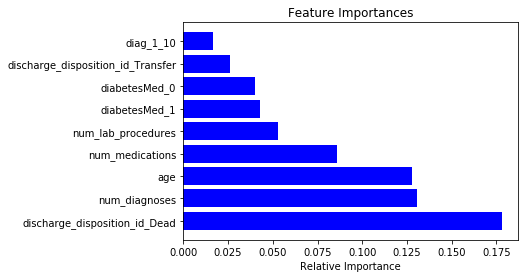

```python
%matplotlib inline

features = X_train.columns
importances = clf.feature_importances_
# indices = np.argsort(importances)
indices = np.argsort(importances)[:-10:-1]

plt.title('Feature Importances')
plt.barh(range(len(indices)), importances[indices], color='b', align='center')
plt.yticks(range(len(indices)), [features[i] for i in indices])
plt.xlabel('Relative Importance')
plt.show()
```

### Using GridCV

```python
from sklearn.model_selection import GridSearchCV
from sklearn.metrics import classification_report
rfc = RandomForestClassifier(n_jobs=-1, max_features='auto', bootstrap=True)
```

```python
# Use a grid over parameters of interest
parameter_grids = {
    "n_estimators" : [10,100,500],
    "max_depth" : [4,8,12,16,20],
    "min_samples_leaf" : [2, 4]
}
```

```python
parameter_grids
```

```
{'n_estimators': [10, 100, 500],
 'max_depth': [4, 8, 12, 16, 20],
 'min_samples_leaf': [2, 4]}
```

```python
CV_rfc = GridSearchCV(estimator=rfc, param_grid=parameter_grids,cv=5,verbose=3,refit=True)
%time CV_rfc.fit(X=X_train, y=y_train)
```

```
Fitting 5 folds for each of 30 candidates, totalling 150 fits
[CV] max_depth=4, min_samples_leaf=2, n_estimators=10 ................
[CV]  max_depth=4, min_samples_leaf=2, n_estimators=10, score=0.5811742582532387, total=   0.3s
[CV] max_depth=4, min_samples_leaf=2, n_estimators=10 ................
```

```
[Parallel(n_jobs=1)]: Done   1 out of   1 | elapsed:    0.4s remaining:    0.0s
```

```
[CV]  max_depth=4, min_samples_leaf=2, n_estimators=10, score=0.58597994149603, total=   0.2s
[CV] max_depth=4, min_samples_leaf=2, n_estimators=10 ................
```

```
[Parallel(n_jobs=1)]: Done   2 out of   2 | elapsed:    0.9s remaining:    0.0s
```

[output not shown]

[output cut: 240 more lines]

[output not shown]

```
[Parallel(n_jobs=1)]: Done 150 out of 150 | elapsed: 11.0min finished
```

```
Wall time: 11min 15s
```

```
GridSearchCV(cv=5, error_score='raise',
       estimator=RandomForestClassifier(bootstrap=True, class_weight=None, criterion='gini',
            max_depth=None, max_features='auto', max_leaf_nodes=None,
            min_impurity_decrease=0.0, min_impurity_split=None,
            min_samples_leaf=1, min_samples_split=2,
            min_weight_fraction_leaf=0.0, n_estimators=10, n_jobs=-1,
            oob_score=False, random_state=None, verbose=0,
            warm_start=False),
       fit_params=None, iid=True, n_jobs=1,
       param_grid={'n_estimators': [10, 100, 500], 'max_depth': [4, 8, 12, 16, 20], 'min_samples_leaf': [2, 4]},
       pre_dispatch='2*n_jobs', refit=True, return_train_score='warn',
       scoring=None, verbose=3)
```

```python
from sklearn.metrics import accuracy_score
from sklearn.metrics import recall_score

y_pred_test = CV_rfc.predict(X_test)
print(accuracy_score(y_test,y_pred_test))
```

```
0.7826839826839826
```

```python
y_pred_train = CV_rfc.predict(X_train)
print(accuracy_score(y_train,y_pred_train))
```

```
0.9649394066025909
```

```python
print('CV_rfc')
print('Training:')
CV_rfc_train_auc, CV_rfc_train_accuracy, CV_rfc_train_recall, CV_rfc_train_precision, CV_rfc_train_specificity =print_report(y_train,y_pred_train, thresh)
print('Validation:')
CV_rfc_valid_auc, CV_rfc_valid_accuracy, CV_rfc_valid_recall, CV_rfc_valid_precision, CV_rfc_valid_specificity = print_report(y_test,y_pred_test, thresh)
```

```
CV_rfc
Training:
AUC:0.965
accuracy:0.965
recall:0.994
precision:0.939
specificity:0.936
prevalence:0.500

Validation:
AUC:0.547
accuracy:0.783
recall:0.219
precision:0.221
specificity:0.874
prevalence:0.140
```

# G R A D I E N T -- B O O S T I N G

```python
from sklearn.ensemble import GradientBoostingClassifier
gbc =GradientBoostingClassifier(n_estimators=100, learning_rate=0.1,
     max_depth=4, random_state=1)
```

```python
%time gbc.fit(X_train, y_train)
```

```
Wall time: 19.6 s
```

```
GradientBoostingClassifier(criterion='friedman_mse', init=None,
              learning_rate=0.1, loss='deviance', max_depth=4,
              max_features=None, max_leaf_nodes=None,
              min_impurity_decrease=0.0, min_impurity_split=None,
              min_samples_leaf=1, min_samples_split=2,
              min_weight_fraction_leaf=0.0, n_estimators=100,
              presort='auto', random_state=1, subsample=1.0, verbose=0,
              warm_start=False)
```

```python
y_train_preds = gbc.predict(X_train)
y_test_preds = gbc.predict(X_test)

print('Gradient Boosting Classifier')
print('Training:')
gbc_train_auc, gbc_train_accuracy, gbc_train_recall, gbc_train_precision, gbc_train_specificity = print_report(y_train,y_train_preds, thresh)
print('Validation:')
gbc_valid_auc, gbc_valid_accuracy, gbc_valid_recall, gbc_valid_precision, gbc_valid_specificity = print_report(y_test,y_test_preds, thresh)
```

```
Gradient Boosting Classifier
Training:
AUC:0.653
accuracy:0.653
recall:0.739
precision:0.630
specificity:0.566
prevalence:0.500

Validation:
AUC:0.577
accuracy:0.551
recall:0.613
precision:0.178
specificity:0.541
prevalence:0.140
```

# RANDOMIZED SEARCH random forest

```python
from sklearn.model_selection import RandomizedSearchCV

# number of trees
n_estimators = range(200,1000,200)
# maximum number of features to use at each split
max_features = ['auto','sqrt']
# maximum depth of the tree
max_depth = range(1,10,1)
# minimum number of samples to split a node
min_samples_split = range(2,10,2)
# criterion for evaluating a split
criterion = ['gini','entropy']

# random grid

random_grid = {'n_estimators':n_estimators,
              'max_features':max_features,
              'max_depth':max_depth,
              'min_samples_split':min_samples_split,
              'criterion':criterion}

print(random_grid)
```

```
{'n_estimators': range(200, 1000, 200), 'max_features': ['auto', 'sqrt'], 'max_depth': range(1, 10), 'min_samples_split': range(2, 10, 2), 'criterion': ['gini', 'entropy']}
```

```python
from sklearn.metrics import make_scorer, roc_auc_score
auc_scoring = make_scorer(roc_auc_score)
```

```python
# create the randomized search cross-validation
rf_random = RandomizedSearchCV(estimator = rf, param_distributions = random_grid,
                               n_iter = 20, cv = 2, scoring='recall_weighted',
                               verbose = 1, random_state = 1)
```

```python
+%time rf_random.fit(X_train, y_train)
```

```
Fitting 2 folds for each of 20 candidates, totalling 40 fits
```

```
[Parallel(n_jobs=1)]: Done  40 out of  40 | elapsed:  6.7min finished
```

```
Wall time: 6min 54s
```

```
RandomizedSearchCV(cv=2, error_score='raise',
          estimator=RandomForestClassifier(bootstrap=True, class_weight=None, criterion='gini',
            max_depth=6, max_features='auto', max_leaf_nodes=None,
            min_impurity_decrease=0.0, min_impurity_split=None,
            min_samples_leaf=1, min_samples_split=2,
            min_weight_fraction_leaf=0.0, n_estimators=10, n_jobs=1,
            oob_score=False, random_state=1, verbose=0, warm_start=False),
          fit_params=None, iid=True, n_iter=20, n_jobs=1,
          param_distributions={'n_estimators': range(200, 1000, 200), 'max_features': ['auto', 'sqrt'], 'max_depth': range(1, 10), 'min_samples_split': range(2, 10, 2), 'criterion': ['gini', 'entropy']},
          pre_dispatch='2*n_jobs', random_state=1, refit=True,
          return_train_score='warn', scoring='recall_weighted', verbose=1)
```

```python
rf_random.best_params_
```

```
{'n_estimators': 400,
 'min_samples_split': 4,
 'max_features': 'auto',
 'max_depth': 9,
 'criterion': 'gini'}
```

```python
y_train_preds = rf.predict(X_train)
y_test_preds = rf.predict(X_test)

print('Baseline Random Forest')
rf_train_auc_base = roc_auc_score(y_train, y_train_preds)
rf_valid_auc_base = roc_auc_score(y_test, y_test_preds)

print('Training AUC:%.3f'%(rf_train_auc_base))
print('Validation AUC:%.3f'%(rf_valid_auc_base))

print('Optimized Random Forest')
y_train_preds_random = rf_random.best_estimator_.predict(X_train)
y_test_preds_random = rf_random.best_estimator_.predict(X_test)

rf_train_auc = roc_auc_score(y_train, y_train_preds_random)
rf_valid_auc = roc_auc_score(y_test, y_test_preds_random)

print('Training AUC:%.3f'%(rf_train_auc))
print('Validation AUC:%.3f'%(rf_valid_auc))
```

```
Baseline Random Forest
Training AUC:0.616
Validation AUC:0.562
Optimized Random Forest
Training AUC:0.702
Validation AUC:0.579
```

```python
print('Random search random forest')
print('Training:')
rf_random_train_auc, rf_random_train_accuracy, rf_random_train_recall, rf_random_train_precision, rf_random_train_specificity = print_report(y_train,y_train_preds_random, thresh)
print('Validation:')
rf_random_valid_auc, rf_random_valid_accuracy, rf_random_valid_recall, rf_random_valid_precision, rf_random_valid_specificity = print_report(y_test,y_test_preds_random, thresh)
```

```
Random search random forest
Training:
AUC:0.702
accuracy:0.702
recall:0.792
precision:0.671
specificity:0.611
prevalence:0.500

Validation:
AUC:0.579
accuracy:0.586
recall:0.570
precision:0.184
specificity:0.589
prevalence:0.140
```

# RANDOMIZED SGDC

```python
penalty = ['none','l2','l1']
max_iter = range(100,500,100)
alpha = [0.001,0.003,0.01,0.03,0.1,0.3]
random_grid_sgdc = {'penalty':penalty,
              'max_iter':max_iter,
              'alpha':alpha}
# create the randomized search cross-validation
sgdc_random = RandomizedSearchCV(estimator = sgdc, param_distributions = random_grid_sgdc,
                                 n_iter = 20, cv = 2, scoring='recall_weighted',verbose = 0,
                                 random_state = 1)

%time sgdc_random.fit(X_train, y_train)
```

```
Wall time: 2min 39s
```

```
RandomizedSearchCV(cv=2, error_score='raise',
          estimator=SGDClassifier(alpha=0.1, average=False, class_weight=None, epsilon=0.1,
       eta0=0.0, fit_intercept=True, l1_ratio=0.15,
       learning_rate='optimal', loss='hinge', max_iter=None, n_iter=None,
       n_jobs=1, penalty='l2', power_t=0.5, random_state=1, shuffle=True,
       tol=None, verbose=0, warm_start=False),
          fit_params=None, iid=True, n_iter=20, n_jobs=1,
          param_distributions={'penalty': ['none', 'l2', 'l1'], 'max_iter': range(100, 500, 100), 'alpha': [0.001, 0.003, 0.01, 0.03, 0.1, 0.3]},
          pre_dispatch='2*n_jobs', random_state=1, refit=True,
          return_train_score='warn', scoring='recall_weighted', verbose=0)
```

```python
sgdc_random.best_params_
```

```
{'penalty': 'none', 'max_iter': 200, 'alpha': 0.03}
```

```python
y_train_preds = sgdc.predict(X_train)
y_test_preds = sgdc.predict(X_test)

print('Baseline sgdc')
sgdc_train_auc_base = roc_auc_score(y_train, y_train_preds)
sgdc_valid_auc_base = roc_auc_score(y_test, y_test_preds)

print('Training AUC:%.3f'%(sgdc_train_auc_base))
print('Validation AUC:%.3f'%(sgdc_valid_auc_base))
print('Optimized sgdc')
y_train_preds_random = sgdc_random.best_estimator_.predict(X_train)
y_test_preds_random = sgdc_random.best_estimator_.predict(X_test)
sgdc_train_auc = roc_auc_score(y_train, y_train_preds_random)
sgdc_valid_auc = roc_auc_score(y_test, y_test_preds_random)

print('Training AUC:%.3f'%(sgdc_train_auc))
print('Validation AUC:%.3f'%(sgdc_valid_auc))
```

```
Baseline sgdc
Training AUC:0.533
Validation AUC:0.528
Optimized sgdc
Training AUC:0.588
Validation AUC:0.577
```

```python
print('Training:')
sgdc_train_auc, sgdc_train_accuracy, sgdc_train_recall, sgdc_train_precision, sgdc_train_specificity =print_report(y_train, y_train_preds_random, thresh)
print('Validation:')
sgdc_valid_auc, sgdc_valid_accuracy, sgdc_valid_recall, sgdc_valid_precision, sgdc_valid_specificity = print_report(y_test, y_test_preds_random, thresh)
```

```
Training:
AUC:0.588
accuracy:0.588
recall:0.616
precision:0.583
specificity:0.559
prevalence:0.500

Validation:
AUC:0.577
accuracy:0.556
recall:0.606
precision:0.179
specificity:0.548
prevalence:0.140
```

# TRYING TO OPTIMIZE GRADIENT BOOSTING CLASSIFIER

```python
y_train = upsampled.readmitted
X_train = upsampled.drop('readmitted', axis=1)
```

```python
# number of trees
n_estimators = range(100,500,100)

# maximum depth of the tree
max_depth = range(1,4,1)

# learning rate
learning_rate = [0.001,0.01,0.1]

# random grid

random_grid_gbc = {'n_estimators':n_estimators,
              'max_depth':max_depth,
              'learning_rate':learning_rate}

# create the randomized search cross-validation
gbc_random = RandomizedSearchCV(estimator = gbc, param_distributions = random_grid_gbc,
                                n_iter = 20, cv = 2, scoring='recall_weighted',
                                verbose = 2, random_state = 1)


%time gbc_random.fit(X_train, y_train)
```

```
Fitting 2 folds for each of 20 candidates, totalling 40 fits
[CV] n_estimators=300, max_depth=2, learning_rate=0.1 ................
[CV] . n_estimators=300, max_depth=2, learning_rate=0.1, total=   8.9s
[CV] n_estimators=300, max_depth=2, learning_rate=0.1 ................
```

```
[Parallel(n_jobs=1)]: Done   1 out of   1 | elapsed:    9.2s remaining:    0.0s
```

[output not shown]

[output cut: 22 more lines]

```
[CV]  n_estimators=300, max_depth=1, learning_rate=0.01, total=   4.6s
[CV] n_estimators=300, max_depth=1, learning_rate=0.01 ...............
[CV]  n_estimators=300, max_depth=1, learning_rate=0.01, total=   4.5s
[CV] n_estimators=300, max_depth=3, learning_rate=0.001 ..............
[CV]  n_estimators=300, max_depth=3, learning_rate=0.001, total=  18.3s
[CV] n_estimators=300, max_depth=3, learning_rate=0.001 ..............
[CV]  n_estimators=300, max_depth=3, learning_rate=0.001, total=  18.8s
[CV] n_estimators=100, max_depth=3, learning_rate=0.1 ................
[CV] . n_estimators=100, max_depth=3, learning_rate=0.1, total=   6.0s
[CV] n_estimators=100, max_depth=3, learning_rate=0.1 ................
[CV] . n_estimators=100, max_depth=3, learning_rate=0.1, total=   6.2s
[CV] n_estimators=300, max_depth=3, learning_rate=0.01 ...............
[CV]  n_estimators=300, max_depth=3, learning_rate=0.01, total=  20.6s
[CV] n_estimators=300, max_depth=3, learning_rate=0.01 ...............
[CV]  n_estimators=300, max_depth=3, learning_rate=0.01, total=  20.9s
```

```
[Parallel(n_jobs=1)]: Done  40 out of  40 | elapsed:  6.9min finished
```

```
Wall time: 7min 27s
```

```
RandomizedSearchCV(cv=2, error_score='raise',
          estimator=GradientBoostingClassifier(criterion='friedman_mse', init=None,
              learning_rate=0.1, loss='deviance', max_depth=4,
              max_features=None, max_leaf_nodes=None,
              min_impurity_decrease=0.0, min_impurity_split=None,
              min_samples_leaf=1, min_samples_split=2,
              min_weight_fraction_leaf=0.0, n_estimators=100,
              presort='auto', random_state=1, subsample=1.0, verbose=0,
              warm_start=False),
          fit_params=None, iid=True, n_iter=20, n_jobs=1,
          param_distributions={'n_estimators': range(100, 500, 100), 'max_depth': range(1, 4), 'learning_rate': [0.001, 0.01, 0.1]},
          pre_dispatch='2*n_jobs', random_state=1, refit=True,
          return_train_score='warn', scoring='recall_weighted', verbose=2)
```

```python
gbc_random.best_params_
```

```
{'n_estimators': 300, 'max_depth': 3, 'learning_rate': 0.1}
```

```python
y_train_preds = gbc.predict(X_train)
y_test_preds = gbc.predict(X_test)

print('Baseline gbc')
gbc_train_auc_base = roc_auc_score(y_train, y_train_preds)
gbc_test_auc_base = roc_auc_score(y_test, y_test_preds)

print('Training AUC:%.3f'%(gbc_train_auc_base))
print('Validation AUC:%.3f'%(gbc_test_auc_base))

print('Optimized gbc')
y_train_preds_random = gbc_random.best_estimator_.predict(X_train)
y_test_preds_random = gbc_random.best_estimator_.predict(X_test)
gbc_train_auc = roc_auc_score(y_train, y_train_preds_random)
gbc_test_auc = roc_auc_score(y_test, y_test_preds_random)

print('Training AUC:%.3f'%(gbc_train_auc))
print('Validation AUC:%.3f'%(gbc_test_auc))
```

```
Baseline gbc
Training AUC:0.652
Validation AUC:0.577
Optimized gbc
Training AUC:0.673
Validation AUC:0.586
```

```python
print('Training:')
gbc_train_auc, gbc_train_accuracy, gbc_train_recall, gbc_train_precision, gbc_train_specificity =print_report(y_train, y_train_preds_random, thresh)
print('Validation:')
gbc_valid_auc, gbc_valid_accuracy, gbc_valid_recall, gbc_valid_precision, gbc_valid_specificity = print_report(y_test, y_test_preds_random, thresh)
```

```
Training:
AUC:0.673
accuracy:0.673
recall:0.750
precision:0.650
specificity:0.597
prevalence:0.500

Validation:
AUC:0.586
accuracy:0.578
recall:0.595
precision:0.186
specificity:0.576
prevalence:0.140
```

# X G -- B O O S T -- C L A S S I F I E R

```python
X.readmitted.value_counts()
```

[output not shown]

```python
y_train = upsampled.readmitted
X_train = upsampled.drop('readmitted', axis=1)
```

```python
XGB_model = XGBClassifier(n_estimators=500, gamma=0.5,learning_rate=0.1)
%time XGB_model.fit(X_train, y_train)
y_pred = XGB_model.predict(X_test)
print(accuracy_score(y_test,y_pred))
print(recall_score(y_test, y_pred))
```

```
Wall time: 1min 39s
0.5865800865800865
0.5851393188854489
```

```python
print('XG--boost--classifier')
print('Validation:')
XGB_model_random_valid_auc, XGB_model_random_valid_accuracy, XGB_model_random_valid_recall, XGB_model_random_valid_precision, XGB_model_random_valid_specificity = print_report(y_test,y_pred, thresh)
```

```
XG--boost--classifier
Validation:
AUC:0.586
accuracy:0.587
recall:0.585
precision:0.187
specificity:0.587
prevalence:0.140
```

# GRIDCV_XGB_classifier

```python
from sklearn.model_selection import GridSearchCV
```

```python
XGB = XGBClassifier(n_jobs=-1)

# Use a grid over parameters of interest
param_grid = {
     'colsample_bytree': np.linspace(0.5, 0.9, 2),
     'n_estimators':[100],
     'max_depth': [4, 5]
}


CV_XGB = GridSearchCV(estimator=XGB, param_grid=param_grid, cv= 10, scoring='recall_weighted')
```

```python
y_train = upsampled.readmitted
X_train = upsampled.drop('readmitted', axis=1)
```

```python
%time CV_XGB.fit(X = X_train, y=y_train)
```

[output not shown]

[output cut: 105 more lines]

[output not shown]

```
Wall time: 13min 38s
```

```
GridSearchCV(cv=10, error_score='raise',
       estimator=XGBClassifier(base_score=0.5, booster='gbtree', colsample_bylevel=1,
       colsample_bytree=1, gamma=0, learning_rate=0.1, max_delta_step=0,
       max_depth=3, min_child_weight=1, missing=None, n_estimators=100,
       n_jobs=-1, nthread=None, objective='binary:logistic',
       random_state=0, reg_alpha=0, reg_lambda=1, scale_pos_weight=1,
       seed=None, silent=True, subsample=1),
       fit_params=None, iid=True, n_jobs=1,
       param_grid={'colsample_bytree': array([0.5, 0.9]), 'n_estimators': [100], 'max_depth': [4, 5]},
       pre_dispatch='2*n_jobs', refit=True, return_train_score='warn',
       scoring='recall_weighted', verbose=0)
```

```python
# Find best model
best_xgb_model = CV_XGB.best_estimator_
print (CV_XGB.best_score_, CV_XGB.best_params_)
```

```
0.6632051817801923 {'colsample_bytree': 0.9, 'max_depth': 5, 'n_estimators': 100}
```

```python
y_pred_cv = CV_XGB.predict(X_test)
print(accuracy_score(y_test,y_pred_cv))
print(recall_score(y_test, y_pred_cv))
```

```
0.5767676767676768
0.6016511867905057
```

```python
print('CV--XG--boost--classifier')
print('Validation:')
CV_XGB_random_valid_auc, CV_XGB_random_valid_accuracy, CV_XGB_random_valid_recall, CV_XGB_random_valid_precision, CV_XGB_random_valid_specificity = print_report(y_test,y_pred_cv, thresh)
```

```
CV--XG--boost--classifier
Validation:
AUC:0.587
accuracy:0.577
recall:0.602
precision:0.186
specificity:0.573
prevalence:0.140
```

## LIST OF MODELS :-

###### Logistic Regression

###### Stochastic Gradient Descent

###### Naive Bayes classifier

###### Decision tree

###### Random forest classifier - rf

###### Random forest classifier - clf

###### Gridcv and random forest - rfc

###### Gradient boosting

###### Randomized search random forest - RF_RANDOM(RF)

###### Randomized Sgdc

###### Randomized cv gradient boosted

###### XG boost classifier

###### Gridcv_xgb

[output not shown]

### What the confusion matrix means for us here.

##### true positives (TP): These are cases in which we predicted yes (they have the disease), and they do have the disease.

##### true negatives (TN): We predicted no, and they don't have the disease.

##### false positives (FP): We predicted yes, but they don't actually have the disease. (Also known as a "Type I error.")

##### false negatives (FN): We predicted no, but they actually do have the disease. (Also known as a "Type II error.")

##### Accuracy: Overall, how often is the classifier correct?

(TP+TN)/total - All my models here have a range of accuracies. However, as accuracy increases, recall starts to decrease.

##### Misclassification Rate: Overall, how often is it wrong?

(FP+FN)/total -

##### True Positive Rate: When it's actually yes, how often does it predict yes?

TP/actual yes - In our model, class 1 recall should be high. also known as "Sensitivity" or "Recall"

##### False Positive Rate: When it's actually no, how often does it predict yes?

FP/actual no -

##### True Negative Rate: When it's actually no, how often does it predict no?

TN/actual no equivalent to 1 minus False Positive Rate also known as "Specificity"

##### Precision: When it predicts yes, how often is it correct?

TP/predicted yes - when a model predicts 1 or zero how many times is each predictio correct

##### Prevalence: How often does the yes condition actually occur in our sample?

actual yes/total - to check the class distribution.